# Project-Applied Statistics

## Part One - QUESTION BASED

Please answer the following questions with all relevant assumptions, explanation and details.

## 1. Question: Please refer the table below to answer below questions:

| Planned to purchase Product A | Actually placed and order for Product A - Yes | Actually placed and order for Product A - No | Total |
| --- | --- | --- | --- |
| YES | 400 | 100 | 500 |
| NO | 200 | 1300 | 1500 |
| TOTAL | 600 | 1400 | 2000 |

##### 1. Refer to the above table and find the joint probability of the people who planned to purchase and actually placed an order.

```python
#Solution 1
#P1=P(People who planned to purchase and Actually placed an order)
P1 = 400/2000
print("Probability of the people who planned to purchase and actually placed an order = %1.2f" % P1)
```

```
Probability of the people who planned to purchase and actually placed an order = 0.20
```

##### 2. Refer to the above table and find the joint probability of the people who planned to purchase and actually placed an order, given that people planned to purchase.

```python
#Solution 2
#P1 = P(People who planned to purchase and Actually placed an order)
P1 = 400/2000
#P2 = P(People who planned to purchase)
P2 = 500/2000
#P3 = P(P1|P2) = P(People who planned to purchase and Actually placed an order given that people planned to purchase) = P1/P2
P3 = P1/P2
print('The joint probability of the people who planned to purchase and actually placed an order, given that people planned to purchase = %1.2f'%P3)
```

```
The joint probability of the people who planned to purchase and actually placed an order, given that people planned to purchase = 0.80
```

## 2. Question: An electrical manufacturing company conducts quality checks at specified periods on the products it manufactures. Historically, the failure rate for the manufactured item is 5%. Suppose a random sample of 10 manufactured items is selected. Answer the following questions.

##### A. Probability that none of the items are defective?

```python
#The question satisfies Binomial Distribution, therefore we use python package scipy.stats
import numpy as np
import scipy.stats as stats
```

```python
p1 = 0.05 #Probability of failed item manufactured
n1 = 10   #Number of samples
k1 = np.arange(0,11) #Sample array of possible defective items
print(k1)
binom1 = stats.binom.pmf(k1,n1,p1) #Using the probability mass function we can obtain the probability of each outcome and store it in an array
binom1
```

```
[ 0  1  2  3  4  5  6  7  8  9 10]
```

```
array([5.98736939e-01, 3.15124705e-01, 7.46347985e-02, 1.04750594e-02,
       9.64808106e-04, 6.09352488e-05, 2.67259863e-06, 8.03789063e-08,
       1.58642578e-09, 1.85546875e-11, 9.76562500e-14])
```

```python
#Solution 1

#Probability for none of the items are defective will be Probability of 0 defective item, therefore binom1[0]
print(' Probability that none of the items are defective = %1.4f'% binom1[0])
```

```
 Probability that none of the items are defective = 0.5987
```

##### B. Probability that exactly one of the items is defective?

```python
#Solution 2
#Probability for exactly one of the items is defective will be Probability of 1 defective item, therefore binom1[1]
print('Probability that exactly one of the items is defective = %1.4f' % binom1[1])
```

```
Probability that exactly one of the items is defective = 0.3151
```

##### C. Probability that two or fewer of the items are defective?

```python
#Solution 3
#Probability for two or fewer of the items are defective will be Sum of probabilities of 0,1,2 defective items,
#therefore binom1[0]+binom1[1]+binom1[2]
sum_fewer_or_two = binom1[0]+binom1[1]+binom1[2]
print('Probability that two or fewer of the items are defective = %1.4f' %sum_fewer_or_two)
```

```
Probability that two or fewer of the items are defective = 0.9885
```

##### D. Probability that three or more of the items are defective ?

```python
#Solution 4
#Probabilities for three or more of the items are defective will be Sum of probabilities of 3,4,5,6,7,8,9,10 defective items,
#We can find it by either adding the probabilities from 3 to 10 defective items or we can subtract the probability of 0,1,2 defective items from the total probability of 1
# i.e 1-sum of probability of (0,1,2) defective items

sum_more_or_two = 1 - sum_fewer_or_two
print('Probability that three or more of the items are defective = %1.4f'%sum_more_or_two)
```

```
Probability that three or more of the items are defective = 0.0115
```

## 3. Question: A car salesman sells on an average 3 cars per week

##### A. Probability that in a given week he will sell some cars.

```python
#The question satisfies Poisson Distribution, therefore we use python package scipy.stats

rate1 = 3 #average rate, denoted with lambda in the formula for poisson distribution

k2 = np.arange(0,11) #a numpy array of different no. of successes ranging from 0 to 19 to construct a probability distribution

k2
```

```
array([ 0,  1,  2,  3,  4,  5,  6,  7,  8,  9, 10])
```

```python
#calculating the distribution and storing the distribution of probablitites in an array

poisson1 = stats.poisson.pmf(k2,rate1)
poisson1
```

```
array([0.04978707, 0.14936121, 0.22404181, 0.22404181, 0.16803136,
       0.10081881, 0.05040941, 0.02160403, 0.00810151, 0.0027005 ,
       0.00081015])
```

```python
#Solution 1

#The probability that in a given week he will sell some cars means he will not sell Zero cars,
#so we can find the probability of some cars by calculating probability of selling zero cars and subtracting it from 1 (1 - probability[0])

some_cars = 1 - poisson1[0]
print('Probability that in a given week he will sell some cars = %1.4f'%some_cars)
```

```
Probability that in a given week he will sell some cars = 0.9502
```

##### B. Probability that in a given week he will sell 2 or more but less than 5 cars

```python
#Solution 2
#We can calculate probability that in a given week he will sell 2 or more but less than 5 cars, by subtracting the sum of probability of selling 2,3 and 4 from total probability 1

sum_more2_less5 = 1 - (poisson1[2]+poisson1[3]+poisson1[4])
print('Probability that in a given week he will sell 2 or more but less than 5 cars = %1.4f'%sum_more2_less5)
```

[output not shown]

##### C. Plot the poisson distribution function for cumulative probability of cars sold per-week vs number of cars sold per-week

```python
#Solution 3
#To find cumilative probability we can use  stats.poisson.cdf
poisson1_cumilative = stats.poisson.cdf(k2,rate1)
print(poisson1_cumilative) #The cumilative probability of cars sold per week
```

```
[0.04978707 0.19914827 0.42319008 0.64723189 0.81526324 0.91608206
 0.96649146 0.9880955  0.99619701 0.99889751 0.99970766]
```

```python
import matplotlib.pyplot as plt
%matplotlib inline
```

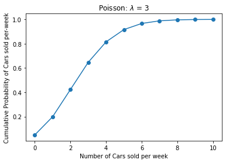

```python
plt.plot(k2,poisson1_cumilative,'-o')
plt.title('Poisson: $\lambda$ = %i ' % rate1)
plt.xlabel("Number of Cars sold per week")
plt.ylabel("Cumulative Probability of Cars sold per-week")
plt.show()
```

## 4. Question: Accuracy in understanding orders for a speech based bot at a restaurant is important for the Company X which has designed, marketed and launched the product for a contactless delivery due to the COVID-19 pandemic. Recognition accuracy that measures the percentage of orders that are taken correctly is 86.8%. Suppose that you place order with the bot and two friends of yours independently place orders with the same bot. Answer the following questions.

##### A. What is the probability that all three orders will be recognised correctly?

```python
#This question satisfies a binomial distribution.
p2 = 0.868   #Percentage of orders that are taken correctly is 86.8%
n2 = 3       #Number of orders
k3 = np.arange(0,4) #Array of possible outcomes
print(k3)
binom2 = stats.binom.pmf(k3,n2,p2) #Using pmf we can find the probability of each outcome.
print(binom2)
```

```
[0 1 2 3]
[0.00229997 0.0453721  0.2983559  0.65397203]
```

```python
#Solution 1
#Probability that all three orders will be recognised correctly,will be the probability of exactly 3 orders taken correctly.
print('Probability that all three orders will be recognised correctly = %1.4f'%binom2[3])
```

```
Probability that all three orders will be recognised correctly = 0.6540
```

##### B. What is the probability that none of the three orders will be recognised correctly?

```python
#Solution 2
print('Probability that none of the three orders will be recognised correctly = %1.4f'%binom2[0])
```

```
Probability that none of the three orders will be recognised correctly = 0.0023
```

##### C. What is the probability that at least two of the three orders will be recognised correctly?

```python
#Solution 3
#We can find probability that at least two of the three orders will be recognised correctly by adding probability of 2 and 3 orders taken correctly.
print('Probability that at least two of the three orders will be recognised correctly = %1.4f'%(binom2[2]+binom2[3]))
```

```
Probability that at least two of the three orders will be recognised correctly = 0.9523
```

## 5. Question: A group of 300 professionals sat for a competitive exam. The results show the information of marks obtained by them have a mean of 60 and a standard deviation of 12. The pattern of marks follows a normal distribution. Answer the following questions.

##### A. What is the percentage of students who score more than 80

```python
mean1 = 60
sd1 = 12
```

```python
#Solution 1
#We can solve normal distribution by standardizing the values and finding the cdf
z1 = (80-mean1)/sd1 #Standardizing
print('Z-Value = %1.4f'%z1)
#We can use Z value to calculate the probability or the area under curve to the left of this z value
normal1 = 1 - stats.norm.cdf(z1) #The probability (area) to the right is calculated as (1 - probability to the left)

print('Percentage of students who score more than 80 = %1.2f%%' %(normal1*100))
```

```
Z-Value = 1.6667
Percentage of students who score more than 80 = 4.78%
```

##### B. What is the percentage of students who score less than 50.

```python
#Solution 2
z2 = (50-mean1)/sd1
print('Z-Value = %1.4f'%z2)
#We can use Z value to calculate the probability or the area under curve to the left of this z value
normal2 = stats.norm.cdf(z2)
print('Percentage of students who score less than 50 = %1.2f%%' %(normal2*100))
```

```
Z-Value = -0.8333
Percentage of students who score less than 50 = 20.23%
```

##### C. What should be the distinction mark if the highest 10% of students are to be awarded distinction?

```python
#Solution 3
normal3 = 100-10 #The percentage of students that are not awarded distinction
normal3=normal3/100
#Since we got the percentage, we can calculate the z value using the stats.norm.ppf (Percent Point Function) function
z3 = stats.norm.ppf(normal3)
print('The Z value = %1.4f'%z3)
#Since we got Z value we can find the x or the corresponding mark from the equation z = (x-mean)/standard_deviation
dist = (z3*sd1)+mean1
dist
print('The distinction mark if the highest 10%% of students are to be awarded distinction = %2.2f'%dist)
```

```
The Z value = 1.2816
The distinction mark if the highest 10% of students are to be awarded distinction = 75.38
```

## 6. Question: Explain 1 real life industry scenario [other than the ones mentioned above] where you can use the concepts learnt in this module of Applied statistics to get a data driven business solution.

Company-X is an EV Charging station providers. They have huge network of charging stations in the state of Kerala. Since the demand for electric vehicles has been growing, the company has decided to increase the number of charging slots at charging stations that have a high demand. They drafted a criteria for this upgrading, which had a condition that the probability of number of cars arriving at a charging station in an hour must be greater than the probability of cars the station can hold in an hour.

We can use poisson distribution to find the probability. For eg:

Question 1) On an average 3 cars arrive every 1 hour at a charging station which have a capacity of 4 cars. What will be the probability that more than 4 cars will arrive at the station in a given hour?

```python
#solution 1
rate2 = 3 #Average no: of cars in an hour
k4 = np.arange(0,11)
k4
```

```
array([ 0,  1,  2,  3,  4,  5,  6,  7,  8,  9, 10])
```

```python
poisson2 = stats.poisson.pmf(k4,rate2)
poisson2
```

```
array([0.04978707, 0.14936121, 0.22404181, 0.22404181, 0.16803136,
       0.10081881, 0.05040941, 0.02160403, 0.00810151, 0.0027005 ,
       0.00081015])
```

```python
#We need to find probability of more than 4 cars, we need to find the sum of probability of 5,6,7,8,9,10 cars arriving,
#for that we can use the cumulative distribution function.
poisson2_cumulative = stats.poisson.cdf(k4,rate2)
poisson2_cumulative
```

```
array([0.04978707, 0.19914827, 0.42319008, 0.64723189, 0.81526324,
       0.91608206, 0.96649146, 0.9880955 , 0.99619701, 0.99889751,
       0.99970766])
```

```python
#Now we have the sum of probabilities of each occurence,Inorder to find the sum of probability of 5,6,7,8,9,10 cars arriving
#we can subtract the sum of probability of 0 to 4 cars arriving and subtract it from total probability of 1
morethan_4 = 1 - poisson2_cumulative[4]
print("The probability that more than 4 cars will arrive at the station in a given hour = %f" %morethan_4)
```

```
The probability that more than 4 cars will arrive at the station in a given hour = 0.184737
```

From the above analysis we can conclude that the charging station that we considered needs an upgradation since it satisfies the criteria. ie poisson2_cumulative > poisson2[4] (0.184737 > 0.16803136)

## Part Two - PROJECT BASED

**• DOMAIN :** Sports

**• CONTEXT :** Company X manages the men's top professional basketball division of the American league system. The dataset contains information on all the teams that have participated in all the past tournaments. It has data about how many baskets each team scored, conceded, how many times they came within the first 2 positions, how many tournaments they have qualified, their best position in the past, etc.

**• DATA DESCRIPTION :** Basketball.csv - The data set contains information on all the teams so far participated in all the past tournaments.

**• ATTRIBUTE INFORMATION :**

1. Team: Team’s name
2. Tournament: Number of played tournaments.
3. Score: Team’s score so far.
4. PlayedGames: Games played by the team so far.
5. WonGames: Games won by the team so far.
6. DrawnGames: Games drawn by the team so far.
7. LostGames: Games lost by the team so far.
8. BasketScored: Basket scored by the team so far.
9. BasketGiven: Basket scored against the team so far.
10. TournamentChampion: How many times the team was a champion of the tournaments so far.
11. Runner-up: How many times the team was a runners-up of the tournaments so far.
12. TeamLaunch: Year the team was launched on professional basketball.
13. HighestPositionHeld: Highest position held by the team amongst all the tournaments played.

**• PROJECT OBJECTIVE :** Company’s management wants to invest on proposal on managing some of the best teams in the league. The analytics department has been assigned with a task of creating a report on the performance shown by the teams. Some of the older teams are already in contract with competitors. Hence Company X wants to understand which teams they can approach which will be a deal win for them.

**Steps and tasks :**

1. Read the data set, clean the data and prepare a final dataset to be used for analysis.
2. Perform detailed statistical analysis and EDA using univariate, bi-variate and multivariate EDA techniques to get a data driven insights on recommending which teams they can approach which will be a deal win for them.. Also as a data

and statistics expert you have to develop a detailed performance report using this data. Hint: Use statistical techniques and visualisation techniques to come up with useful metrics and reporting. Find out the best performing team, oldest team, team with highest goals, team with lowest performance etc. and many more. These are just random examples please use your best analytical approach to build this report. You can mix match columns to create new ones which can be used for better analysis. Create your own features if required. Be highly experimental and analytical here to find hidden patterns. Use graphical interactive libraries to enable you to publish interactive plots in python.

3. Please include any improvements or suggestions to the association management on quality, quantity, variety, velocity,

veracity etc. on the data points collected by the association to perform a better data analysis in future.

### EDA of Data

```python
import pandas as pd
```

```python
basket_data = pd.read_csv('Basketball.csv')
basket_data.head(20) #view the first 20 rows of data
```

|  | Team | Tournament | Score | PlayedGames | WonGames | DrawnGames | LostGames | BasketScored | BasketGiven | TournamentChampion | Runner-up | TeamLaunch | HighestPositionHeld |
| --- | --- | --- | --- | --- | --- | --- | --- | --- | --- | --- | --- | --- | --- |
| 0 | Team 1 | 86 | 4385 | 2762 | 1647 | 552 | 563 | 5947 | 3140 | 33 | 23 | 1929 | 1 |
| 1 | Team 2 | 86 | 4262 | 2762 | 1581 | 573 | 608 | 5900 | 3114 | 25 | 25 | 1929 | 1 |
| 2 | Team 3 | 80 | 3442 | 2614 | 1241 | 598 | 775 | 4534 | 3309 | 10 | 8 | 1929 | 1 |
| 3 | Team 4 | 82 | 3386 | 2664 | 1187 | 616 | 861 | 4398 | 3469 | 6 | 6 | 1931to32 | 1 |
| 4 | Team 5 | 86 | 3368 | 2762 | 1209 | 633 | 920 | 4631 | 3700 | 8 | 7 | 1929 | 1 |
| 5 | Team 6 | 73 | 2819 | 2408 | 990 | 531 | 887 | 3680 | 3373 | 1 | 4 | 1934-35 | 1 |
| 6 | Team 7 | 82 | 2792 | 2626 | 948 | 608 | 1070 | 3609 | 3889 | - | - | 1929 | 3 |
| 7 | Team 8 | 70 | 2573 | 2302 | 864 | 577 | 861 | 3228 | 3230 | 2 | 3 | 1929 | 1 |
| 8 | Team 9 | 58 | 2109 | 1986 | 698 | 522 | 766 | 2683 | 2847 | - | 1 | 1939-40 | 2 |
| 9 | Team 10 | 51 | 1884 | 1728 | 606 | 440 | 682 | 2159 | 2492 | 1 | - | 1932-33 | 1 |
| 10 | Team 11 | 45 | 1814 | 1530 | 563 | 392 | 575 | 2052 | 2188 | 1 | 5 | 1941to42 | 1 |
| 11 | Team 12 | 51 | 1789 | 1698 | 586 | 389 | 723 | 2278 | 2624 | - | - | 1939-40 | 4 |
| 12 | Team 13 | 42 | 1471 | 1466 | 463 | 384 | 619 | 1767 | 2180 | - | - | 1948-49 | 4 |
| 13 | Team 14 | 44 | 1416 | 1428 | 453 | 336 | 639 | 1843 | 2368 | - | 1 | 1929 | 2 |
| 14 | Team 15 | 43 | 1389 | 1458 | 471 | 358 | 629 | 1753 | 2152 | - | 1 | 1944_45 | 2 |
| 15 | Team 16 | 37 | 1351 | 1318 | 426 | 327 | 565 | 1500 | 1834 | - | - | 1935-36 | 4 |
| 16 | Team 17 | 36 | 1314 | 1255 | 390 | 330 | 535 | 1421 | 1763 | - | - | 1949_50 | 4 |
| 17 | Team 18 | 38 | 1174 | 1192 | 408 | 292 | 492 | 1642 | 1951 | - | - | 1933to34 | 3 |
| 18 | Team 19 | 27 | 1148 | 988 | 333 | 256 | 399 | 1182 | 1371 | - | - | 1960-61 | 3 |
| 19 | Team 20 | 33 | 1020 | 1096 | 367 | 242 | 487 | 1347 | 1746 | - | 1 | 1951-52 | 2 |

```python
basket_data.tail(20) #view the last 20 rows of the data
```

|  | Team | Tournament | Score | PlayedGames | WonGames | DrawnGames | LostGames | BasketScored | BasketGiven | TournamentChampion | Runner-up | TeamLaunch | HighestPositionHeld |
| --- | --- | --- | --- | --- | --- | --- | --- | --- | --- | --- | --- | --- | --- |
| 41 | Team 42 | 6 | 150 | 180 | 53 | 44 | 83 | 165 | 221 | - | - | 1963-64 | 7 |
| 42 | Team 43 | 4 | 148 | 152 | 37 | 37 | 78 | 155 | 253 | - | - | 1999to00 | 17 |
| 43 | Team 44 | 3 | 132 | 114 | 35 | 27 | 52 | 139 | 167 | - | - | 2014-15 | 10 |
| 44 | Team 45 | 7 | 107 | 130 | 43 | 21 | 66 | 227 | 308 | - | - | 1929 | 3 |
| 45 | Team 46 | 3 | 96 | 114 | 26 | 44 | 44 | 101 | 139 | - | - | 1990-91 | 9 |
| 46 | Team 47 | 4 | 91 | 116 | 34 | 16 | 66 | 181 | 295 | - | - | 1947-48 | 7 |
| 47 | Team 48 | 2 | 83 | 80 | 20 | 23 | 37 | 62 | 117 | - | - | 1996-97 | 17 |
| 48 | Team 49 | 2 | 81 | 80 | 19 | 24 | 37 | 70 | 115 | - | - | 1995-96 | 19 |
| 49 | Team 50 | 4 | 76 | 108 | 30 | 16 | 62 | 145 | 252 | - | - | 1945-46 | 10 |
| 50 | Team 51 | 3 | 71 | 90 | 29 | 13 | 48 | 121 | 183 | - | - | 1953-54 | 14 |
| 51 | Team 52 | 4 | 56 | 72 | 21 | 14 | 37 | 153 | 184 | - | - | 1929 | 6 |
| 52 | Team 53 | 2 | 52 | 68 | 17 | 18 | 33 | 71 | 116 | - | - | 1979-80 | 10 |
| 53 | Team 54 | 3 | 42 | 54 | 18 | 6 | 30 | 97 | 131 | - | - | 1929 | 8 |
| 54 | Team 55 | 2 | 40 | 68 | 13 | 14 | 41 | 70 | 182 | - | - | 1950-51 | 16 |
| 55 | Team 56 | 1 | 35 | 38 | 8 | 11 | 19 | 36 | 55 | - | - | 2016_17 | 17 |
| 56 | Team 57 | 1 | 34 | 38 | 8 | 10 | 20 | 38 | 66 | - | - | 2009-10 | 20 |
| 57 | Team 58 | 1 | 22 | 30 | 7 | 8 | 15 | 37 | 57 | - | - | 1956-57 | 16 |
| 58 | Team 59 | 1 | 19 | 30 | 7 | 5 | 18 | 51 | 85 | - | - | 1951~52 | 16 |
| 59 | Team 60 | 1 | 14 | 30 | 5 | 4 | 21 | 34 | 65 | - | - | 1955-56 | 15 |
| 60 | Team 61 | 1 | - | - | - | - | - | - | - | - | - | 2017~18 | 9 |

```python
print(basket_data.shape) #shape of data
print(basket_data.size)  #size of data
```

```
(61, 13)
793
```

**Dataset has 61 rows and 13 columns**

```python
basket_data.info() #To check the data types, is there any null values etc
```

```
<class 'pandas.core.frame.DataFrame'>
RangeIndex: 61 entries, 0 to 60
Data columns (total 13 columns):
 #   Column               Non-Null Count  Dtype
---  ------               --------------  -----
 0   Team                 61 non-null     object
 1   Tournament           61 non-null     int64
 2   Score                61 non-null     object
 3   PlayedGames          61 non-null     object
 4   WonGames             61 non-null     object
 5   DrawnGames           61 non-null     object
 6   LostGames            61 non-null     object
 7   BasketScored         61 non-null     object
 8   BasketGiven          61 non-null     object
 9   TournamentChampion   61 non-null     object
 10  Runner-up            61 non-null     object
 11  TeamLaunch           61 non-null     object
 12  HighestPositionHeld  61 non-null     int64
dtypes: int64(2), object(11)
memory usage: 6.3+ KB
```

**The dataset has 2 numerical variable and 11 object variables**

```python
basket_data.isnull().sum()
#To find the number of missing values in each column
```

```
Team                   0
Tournament             0
Score                  0
PlayedGames            0
WonGames               0
DrawnGames             0
LostGames              0
BasketScored           0
BasketGiven            0
TournamentChampion     0
Runner-up              0
TeamLaunch             0
HighestPositionHeld    0
dtype: int64
```

**From the above result we can say there is no missing values which is considered by the function but we have to do more analysis to finalize.**  
**isnull function by default considers only missing value which have NaN as value but the data can have other Non-Standard Missing values too**

**But from observing first 20 and last 20 rows we can see there are missing values which are denoted by '-' and since the numerical values in the data is not automatically converted to int64 data type we can say there maybe Non-Standard Missing values too, so we have to find the total number of missing values or Non-Standard Missing.(ie '-' )**

```python
basket_data.replace('-',np.NaN,inplace=True)

#This piece of code replaces the '-' value with NaN in the dataframe
```

```python
#Checking for null values in rows and finding the row having highest number of null values
basket_data.isna().sum(axis=1).sort_values(ascending=False)
```

```
60    9
36    2
34    2
33    2
32    2
     ..
4     0
3     0
2     0
1     0
0     0
Length: 61, dtype: int64
```

**We can see the 61st row have 9 null values out of the 13 column. It is better to drop the row rather than replacing**

```python
basket_data.drop(60,axis=0,inplace=True)
#Removing the row with higher number of null values
```

```python
#Now we can check for the null values in columns
basket_data.isna().sum()
```

```
Team                    0
Tournament              0
Score                   0
PlayedGames             0
WonGames                0
DrawnGames              0
LostGames               0
BasketScored            0
BasketGiven             0
TournamentChampion     51
Runner-up              47
TeamLaunch              0
HighestPositionHeld     0
dtype: int64
```

```python
basket_data.dropna(axis=1,inplace=True)
##Removing the columns TournamentChampion and Runner-up
```

```python
basket_data
```

|  | Team | Tournament | Score | PlayedGames | WonGames | DrawnGames | LostGames | BasketScored | BasketGiven | TeamLaunch | HighestPositionHeld |
| --- | --- | --- | --- | --- | --- | --- | --- | --- | --- | --- | --- |
| 0 | Team 1 | 86 | 4385 | 2762 | 1647 | 552 | 563 | 5947 | 3140 | 1929 | 1 |
| 1 | Team 2 | 86 | 4262 | 2762 | 1581 | 573 | 608 | 5900 | 3114 | 1929 | 1 |
| 2 | Team 3 | 80 | 3442 | 2614 | 1241 | 598 | 775 | 4534 | 3309 | 1929 | 1 |
| 3 | Team 4 | 82 | 3386 | 2664 | 1187 | 616 | 861 | 4398 | 3469 | 1931to32 | 1 |
| 4 | Team 5 | 86 | 3368 | 2762 | 1209 | 633 | 920 | 4631 | 3700 | 1929 | 1 |
| 5 | Team 6 | 73 | 2819 | 2408 | 990 | 531 | 887 | 3680 | 3373 | 1934-35 | 1 |
| 6 | Team 7 | 82 | 2792 | 2626 | 948 | 608 | 1070 | 3609 | 3889 | 1929 | 3 |
| 7 | Team 8 | 70 | 2573 | 2302 | 864 | 577 | 861 | 3228 | 3230 | 1929 | 1 |
| 8 | Team 9 | 58 | 2109 | 1986 | 698 | 522 | 766 | 2683 | 2847 | 1939-40 | 2 |
| 9 | Team 10 | 51 | 1884 | 1728 | 606 | 440 | 682 | 2159 | 2492 | 1932-33 | 1 |
| 10 | Team 11 | 45 | 1814 | 1530 | 563 | 392 | 575 | 2052 | 2188 | 1941to42 | 1 |
| 11 | Team 12 | 51 | 1789 | 1698 | 586 | 389 | 723 | 2278 | 2624 | 1939-40 | 4 |
| 12 | Team 13 | 42 | 1471 | 1466 | 463 | 384 | 619 | 1767 | 2180 | 1948-49 | 4 |
| 13 | Team 14 | 44 | 1416 | 1428 | 453 | 336 | 639 | 1843 | 2368 | 1929 | 2 |
| 14 | Team 15 | 43 | 1389 | 1458 | 471 | 358 | 629 | 1753 | 2152 | 1944_45 | 2 |
| 15 | Team 16 | 37 | 1351 | 1318 | 426 | 327 | 565 | 1500 | 1834 | 1935-36 | 4 |
| 16 | Team 17 | 36 | 1314 | 1255 | 390 | 330 | 535 | 1421 | 1763 | 1949_50 | 4 |
| 17 | Team 18 | 38 | 1174 | 1192 | 408 | 292 | 492 | 1642 | 1951 | 1933to34 | 3 |
| 18 | Team 19 | 27 | 1148 | 988 | 333 | 256 | 399 | 1182 | 1371 | 1960-61 | 3 |
| 19 | Team 20 | 33 | 1020 | 1096 | 367 | 242 | 487 | 1347 | 1746 | 1951-52 | 2 |
| 20 | Team 21 | 17 | 970 | 646 | 266 | 172 | 208 | 892 | 789 | 1998-99 | 2 |
| 21 | Team 22 | 23 | 667 | 742 | 218 | 175 | 349 | 819 | 1157 | 1941-42 | 6 |
| 22 | Team 23 | 17 | 662 | 652 | 189 | 148 | 305 | 760 | 1088 | 1977-78 | 8 |
| 23 | Team 24 | 21 | 606 | 678 | 203 | 180 | 295 | 750 | 1022 | 1959-60 | 5 |
| 24 | Team 25 | 12 | 553 | 456 | 147 | 112 | 197 | 520 | 633 | 2004to05 | 6 |
| 25 | Team 26 | 20 | 538 | 628 | 184 | 149 | 295 | 716 | 1050 | 1935-36 | 5 |
| 26 | Team 27 | 13 | 510 | 494 | 155 | 128 | 211 | 619 | 744 | 1961-62 | 5 |
| 27 | Team 28 | 18 | 445 | 586 | 145 | 143 | 298 | 607 | 992 | 1940-41 | 11 |
| 28 | Team 29 | 12 | 421 | 380 | 125 | 81 | 174 | 458 | 623 | 1930-31 | 6 |
| 29 | Team 30 | 11 | 416 | 402 | 113 | 95 | 194 | 430 | 632 | 1963-64 | 6 |
| 30 | Team 31 | 12 | 375 | 423 | 123 | 102 | 198 | 422 | 581 | 1974-75 | 7 |
| 31 | Team 32 | 14 | 353 | 426 | 129 | 95 | 202 | 492 | 720 | 1943-44 | 4 |
| 32 | Team 33 | 12 | 343 | 448 | 104 | 127 | 217 | 393 | 662 | 1977-78 | 12 |
| 33 | Team 34 | 9 | 293 | 346 | 96 | 92 | 158 | 291 | 489 | 1987-88 | 7 |
| 34 | Team 35 | 11 | 285 | 334 | 103 | 79 | 152 | 419 | 588 | 1941-42 | 4 |
| 35 | Team 36 | 7 | 277 | 270 | 76 | 76 | 118 | 320 | 410 | 1991_92 | 7 |
| 36 | Team 37 | 6 | 242 | 228 | 62 | 56 | 110 | 244 | 366 | 2007-08 | 8 |
| 37 | Team 38 | 9 | 230 | 282 | 82 | 63 | 137 | 285 | 430 | 1962-63 | 5 |
| 38 | Team 39 | 4 | 190 | 160 | 52 | 45 | 63 | 199 | 241 | 1994-95 | 10 |
| 39 | Team 40 | 5 | 188 | 186 | 50 | 46 | 90 | 202 | 296 | 1978-79 | 8 |
| 40 | Team 41 | 6 | 168 | 204 | 59 | 50 | 95 | 216 | 310 | 1971-72 | 12 |
| 41 | Team 42 | 6 | 150 | 180 | 53 | 44 | 83 | 165 | 221 | 1963-64 | 7 |
| 42 | Team 43 | 4 | 148 | 152 | 37 | 37 | 78 | 155 | 253 | 1999to00 | 17 |
| 43 | Team 44 | 3 | 132 | 114 | 35 | 27 | 52 | 139 | 167 | 2014-15 | 10 |
| 44 | Team 45 | 7 | 107 | 130 | 43 | 21 | 66 | 227 | 308 | 1929 | 3 |
| 45 | Team 46 | 3 | 96 | 114 | 26 | 44 | 44 | 101 | 139 | 1990-91 | 9 |
| 46 | Team 47 | 4 | 91 | 116 | 34 | 16 | 66 | 181 | 295 | 1947-48 | 7 |
| 47 | Team 48 | 2 | 83 | 80 | 20 | 23 | 37 | 62 | 117 | 1996-97 | 17 |
| 48 | Team 49 | 2 | 81 | 80 | 19 | 24 | 37 | 70 | 115 | 1995-96 | 19 |
| 49 | Team 50 | 4 | 76 | 108 | 30 | 16 | 62 | 145 | 252 | 1945-46 | 10 |
| 50 | Team 51 | 3 | 71 | 90 | 29 | 13 | 48 | 121 | 183 | 1953-54 | 14 |
| 51 | Team 52 | 4 | 56 | 72 | 21 | 14 | 37 | 153 | 184 | 1929 | 6 |
| 52 | Team 53 | 2 | 52 | 68 | 17 | 18 | 33 | 71 | 116 | 1979-80 | 10 |
| 53 | Team 54 | 3 | 42 | 54 | 18 | 6 | 30 | 97 | 131 | 1929 | 8 |
| 54 | Team 55 | 2 | 40 | 68 | 13 | 14 | 41 | 70 | 182 | 1950-51 | 16 |
| 55 | Team 56 | 1 | 35 | 38 | 8 | 11 | 19 | 36 | 55 | 2016_17 | 17 |
| 56 | Team 57 | 1 | 34 | 38 | 8 | 10 | 20 | 38 | 66 | 2009-10 | 20 |
| 57 | Team 58 | 1 | 22 | 30 | 7 | 8 | 15 | 37 | 57 | 1956-57 | 16 |
| 58 | Team 59 | 1 | 19 | 30 | 7 | 5 | 18 | 51 | 85 | 1951~52 | 16 |
| 59 | Team 60 | 1 | 14 | 30 | 5 | 4 | 21 | 34 | 65 | 1955-56 | 15 |

```python
basket_data.isnull().sum()
```

```
Team                   0
Tournament             0
Score                  0
PlayedGames            0
WonGames               0
DrawnGames             0
LostGames              0
BasketScored           0
BasketGiven            0
TeamLaunch             0
HighestPositionHeld    0
dtype: int64
```

**We have removed all the null values from the dataframe**

```python
print(basket_data.shape) #shape of data after droping 61th row
print(basket_data.size)  #size of data after droping 61th row
```

```
(60, 11)
660
```

**We notice the column TeamLaunch represents the Year the team was launched on professional basketball. But the data present are not in proper format to read, some contain a year and its next consecutive year, it may be due to their duration for launching or based on sports calender. Since not every team have this duration we consider only the starting year.**  
**We have to filter the proper date**

```python
basket_data['TeamLaunch']
#Year duration is seperated by many methods like 'to','-','_','~'
```

```
0         1929
1         1929
2         1929
3     1931to32
4         1929
5      1934-35
6         1929
7         1929
8      1939-40
9      1932-33
10    1941to42
11     1939-40
12     1948-49
13        1929
14     1944_45
```

[output cut: 46 more lines]

```python
basket_data['TeamLaunch']=basket_data['TeamLaunch'].str.split('-',expand=True)[0]
basket_data['TeamLaunch']
```

```
0         1929
1         1929
2         1929
3     1931to32
4         1929
5         1934
6         1929
7         1929
8         1939
9         1932
10    1941to42
11        1939
12        1948
13        1929
14     1944_45
```

[output cut: 46 more lines]

```python
basket_data['TeamLaunch']=basket_data['TeamLaunch'].str.split('_',expand=True)[0]
basket_data['TeamLaunch']
```

```
0         1929
1         1929
2         1929
3     1931to32
4         1929
5         1934
6         1929
7         1929
8         1939
9         1932
10    1941to42
11        1939
12        1948
13        1929
14        1944
```

[output cut: 46 more lines]

```python
basket_data['TeamLaunch']=basket_data['TeamLaunch'].str.split('~',expand=True)[0]
basket_data['TeamLaunch']
```

```
0         1929
1         1929
2         1929
3     1931to32
4         1929
5         1934
6         1929
7         1929
8         1939
9         1932
10    1941to42
11        1939
12        1948
13        1929
14        1944
```

[output cut: 46 more lines]

```python
basket_data['TeamLaunch']=basket_data['TeamLaunch'].str.split('to',expand=True)[0]
basket_data['TeamLaunch']
```

```
0     1929
1     1929
2     1929
3     1931
4     1929
5     1934
6     1929
7     1929
8     1939
9     1932
10    1941
11    1939
12    1948
13    1929
14    1944
```

[output cut: 46 more lines]

**We have separated and filtered the year from TeamLaunch column by taking delimters 'to','-','_','~'**

```python
basket_data.head()
```

|  | Team | Tournament | Score | PlayedGames | WonGames | DrawnGames | LostGames | BasketScored | BasketGiven | TeamLaunch | HighestPositionHeld |
| --- | --- | --- | --- | --- | --- | --- | --- | --- | --- | --- | --- |
| 0 | Team 1 | 86 | 4385 | 2762 | 1647 | 552 | 563 | 5947 | 3140 | 1929 | 1 |
| 1 | Team 2 | 86 | 4262 | 2762 | 1581 | 573 | 608 | 5900 | 3114 | 1929 | 1 |
| 2 | Team 3 | 80 | 3442 | 2614 | 1241 | 598 | 775 | 4534 | 3309 | 1929 | 1 |
| 3 | Team 4 | 82 | 3386 | 2664 | 1187 | 616 | 861 | 4398 | 3469 | 1931 | 1 |
| 4 | Team 5 | 86 | 3368 | 2762 | 1209 | 633 | 920 | 4631 | 3700 | 1929 | 1 |

**We have almost cleaned the data, but most of the data are in object data type eventhough they are integer values, which will hinder our analysis so we have to convert them to int64 data type**

```python
basket_data.dtypes #Data types of each columns
```

```
Team                   object
Tournament              int64
Score                  object
PlayedGames            object
WonGames               object
DrawnGames             object
LostGames              object
BasketScored           object
BasketGiven            object
TeamLaunch             object
HighestPositionHeld     int64
dtype: object
```

```python
basket_data.loc[:,'Score':'TeamLaunch'] = basket_data.loc[:,'Score':'TeamLaunch'].astype('int64')
# Converting column 'Score' to column 'TeamLaunch' into int64 data type.
```

```python
basket_data.dtypes
# Data type after convertion
```

```
Team                   object
Tournament              int64
Score                   int64
PlayedGames             int64
WonGames                int64
DrawnGames              int64
LostGames               int64
BasketScored            int64
BasketGiven             int64
TeamLaunch              int64
HighestPositionHeld     int64
dtype: object
```

**Now we can start analysing since our data is clean**

```python
basket_data
```

|  | Team | Tournament | Score | PlayedGames | WonGames | DrawnGames | LostGames | BasketScored | BasketGiven | TeamLaunch | HighestPositionHeld |
| --- | --- | --- | --- | --- | --- | --- | --- | --- | --- | --- | --- |
| 0 | Team 1 | 86 | 4385 | 2762 | 1647 | 552 | 563 | 5947 | 3140 | 1929 | 1 |
| 1 | Team 2 | 86 | 4262 | 2762 | 1581 | 573 | 608 | 5900 | 3114 | 1929 | 1 |
| 2 | Team 3 | 80 | 3442 | 2614 | 1241 | 598 | 775 | 4534 | 3309 | 1929 | 1 |
| 3 | Team 4 | 82 | 3386 | 2664 | 1187 | 616 | 861 | 4398 | 3469 | 1931 | 1 |
| 4 | Team 5 | 86 | 3368 | 2762 | 1209 | 633 | 920 | 4631 | 3700 | 1929 | 1 |
| 5 | Team 6 | 73 | 2819 | 2408 | 990 | 531 | 887 | 3680 | 3373 | 1934 | 1 |
| 6 | Team 7 | 82 | 2792 | 2626 | 948 | 608 | 1070 | 3609 | 3889 | 1929 | 3 |
| 7 | Team 8 | 70 | 2573 | 2302 | 864 | 577 | 861 | 3228 | 3230 | 1929 | 1 |
| 8 | Team 9 | 58 | 2109 | 1986 | 698 | 522 | 766 | 2683 | 2847 | 1939 | 2 |
| 9 | Team 10 | 51 | 1884 | 1728 | 606 | 440 | 682 | 2159 | 2492 | 1932 | 1 |
| 10 | Team 11 | 45 | 1814 | 1530 | 563 | 392 | 575 | 2052 | 2188 | 1941 | 1 |
| 11 | Team 12 | 51 | 1789 | 1698 | 586 | 389 | 723 | 2278 | 2624 | 1939 | 4 |
| 12 | Team 13 | 42 | 1471 | 1466 | 463 | 384 | 619 | 1767 | 2180 | 1948 | 4 |
| 13 | Team 14 | 44 | 1416 | 1428 | 453 | 336 | 639 | 1843 | 2368 | 1929 | 2 |
| 14 | Team 15 | 43 | 1389 | 1458 | 471 | 358 | 629 | 1753 | 2152 | 1944 | 2 |
| 15 | Team 16 | 37 | 1351 | 1318 | 426 | 327 | 565 | 1500 | 1834 | 1935 | 4 |
| 16 | Team 17 | 36 | 1314 | 1255 | 390 | 330 | 535 | 1421 | 1763 | 1949 | 4 |
| 17 | Team 18 | 38 | 1174 | 1192 | 408 | 292 | 492 | 1642 | 1951 | 1933 | 3 |
| 18 | Team 19 | 27 | 1148 | 988 | 333 | 256 | 399 | 1182 | 1371 | 1960 | 3 |
| 19 | Team 20 | 33 | 1020 | 1096 | 367 | 242 | 487 | 1347 | 1746 | 1951 | 2 |
| 20 | Team 21 | 17 | 970 | 646 | 266 | 172 | 208 | 892 | 789 | 1998 | 2 |
| 21 | Team 22 | 23 | 667 | 742 | 218 | 175 | 349 | 819 | 1157 | 1941 | 6 |
| 22 | Team 23 | 17 | 662 | 652 | 189 | 148 | 305 | 760 | 1088 | 1977 | 8 |
| 23 | Team 24 | 21 | 606 | 678 | 203 | 180 | 295 | 750 | 1022 | 1959 | 5 |
| 24 | Team 25 | 12 | 553 | 456 | 147 | 112 | 197 | 520 | 633 | 2004 | 6 |
| 25 | Team 26 | 20 | 538 | 628 | 184 | 149 | 295 | 716 | 1050 | 1935 | 5 |
| 26 | Team 27 | 13 | 510 | 494 | 155 | 128 | 211 | 619 | 744 | 1961 | 5 |
| 27 | Team 28 | 18 | 445 | 586 | 145 | 143 | 298 | 607 | 992 | 1940 | 11 |
| 28 | Team 29 | 12 | 421 | 380 | 125 | 81 | 174 | 458 | 623 | 1930 | 6 |
| 29 | Team 30 | 11 | 416 | 402 | 113 | 95 | 194 | 430 | 632 | 1963 | 6 |
| 30 | Team 31 | 12 | 375 | 423 | 123 | 102 | 198 | 422 | 581 | 1974 | 7 |
| 31 | Team 32 | 14 | 353 | 426 | 129 | 95 | 202 | 492 | 720 | 1943 | 4 |
| 32 | Team 33 | 12 | 343 | 448 | 104 | 127 | 217 | 393 | 662 | 1977 | 12 |
| 33 | Team 34 | 9 | 293 | 346 | 96 | 92 | 158 | 291 | 489 | 1987 | 7 |
| 34 | Team 35 | 11 | 285 | 334 | 103 | 79 | 152 | 419 | 588 | 1941 | 4 |
| 35 | Team 36 | 7 | 277 | 270 | 76 | 76 | 118 | 320 | 410 | 1991 | 7 |
| 36 | Team 37 | 6 | 242 | 228 | 62 | 56 | 110 | 244 | 366 | 2007 | 8 |
| 37 | Team 38 | 9 | 230 | 282 | 82 | 63 | 137 | 285 | 430 | 1962 | 5 |
| 38 | Team 39 | 4 | 190 | 160 | 52 | 45 | 63 | 199 | 241 | 1994 | 10 |
| 39 | Team 40 | 5 | 188 | 186 | 50 | 46 | 90 | 202 | 296 | 1978 | 8 |
| 40 | Team 41 | 6 | 168 | 204 | 59 | 50 | 95 | 216 | 310 | 1971 | 12 |
| 41 | Team 42 | 6 | 150 | 180 | 53 | 44 | 83 | 165 | 221 | 1963 | 7 |
| 42 | Team 43 | 4 | 148 | 152 | 37 | 37 | 78 | 155 | 253 | 1999 | 17 |
| 43 | Team 44 | 3 | 132 | 114 | 35 | 27 | 52 | 139 | 167 | 2014 | 10 |
| 44 | Team 45 | 7 | 107 | 130 | 43 | 21 | 66 | 227 | 308 | 1929 | 3 |
| 45 | Team 46 | 3 | 96 | 114 | 26 | 44 | 44 | 101 | 139 | 1990 | 9 |
| 46 | Team 47 | 4 | 91 | 116 | 34 | 16 | 66 | 181 | 295 | 1947 | 7 |
| 47 | Team 48 | 2 | 83 | 80 | 20 | 23 | 37 | 62 | 117 | 1996 | 17 |
| 48 | Team 49 | 2 | 81 | 80 | 19 | 24 | 37 | 70 | 115 | 1995 | 19 |
| 49 | Team 50 | 4 | 76 | 108 | 30 | 16 | 62 | 145 | 252 | 1945 | 10 |
| 50 | Team 51 | 3 | 71 | 90 | 29 | 13 | 48 | 121 | 183 | 1953 | 14 |
| 51 | Team 52 | 4 | 56 | 72 | 21 | 14 | 37 | 153 | 184 | 1929 | 6 |
| 52 | Team 53 | 2 | 52 | 68 | 17 | 18 | 33 | 71 | 116 | 1979 | 10 |
| 53 | Team 54 | 3 | 42 | 54 | 18 | 6 | 30 | 97 | 131 | 1929 | 8 |
| 54 | Team 55 | 2 | 40 | 68 | 13 | 14 | 41 | 70 | 182 | 1950 | 16 |
| 55 | Team 56 | 1 | 35 | 38 | 8 | 11 | 19 | 36 | 55 | 2016 | 17 |
| 56 | Team 57 | 1 | 34 | 38 | 8 | 10 | 20 | 38 | 66 | 2009 | 20 |
| 57 | Team 58 | 1 | 22 | 30 | 7 | 8 | 15 | 37 | 57 | 1956 | 16 |
| 58 | Team 59 | 1 | 19 | 30 | 7 | 5 | 18 | 51 | 85 | 1951 | 16 |
| 59 | Team 60 | 1 | 14 | 30 | 5 | 4 | 21 | 34 | 65 | 1955 | 15 |

```python
basket_data.describe().T
```

|  | count | mean | std | min | 25% | 50% | 75% | max |
| --- | --- | --- | --- | --- | --- | --- | --- | --- |
| Tournament | 60.0 | 24.383333 | 26.884620 | 1.0 | 4.00 | 12.0 | 39.00 | 86.0 |
| Score | 60.0 | 916.450000 | 1138.342899 | 14.0 | 104.25 | 395.5 | 1360.50 | 4385.0 |
| PlayedGames | 60.0 | 810.100000 | 877.465393 | 30.0 | 115.50 | 424.5 | 1345.50 | 2762.0 |
| WonGames | 60.0 | 309.033333 | 408.481395 | 5.0 | 34.75 | 124.0 | 432.75 | 1647.0 |
| DrawnGames | 60.0 | 192.083333 | 201.985508 | 4.0 | 26.25 | 98.5 | 331.50 | 633.0 |
| LostGames | 60.0 | 308.816667 | 294.508639 | 15.0 | 62.75 | 197.5 | 563.50 | 1070.0 |
| BasketScored | 60.0 | 1159.350000 | 1512.063948 | 34.0 | 154.50 | 444.0 | 1669.75 | 5947.0 |
| BasketGiven | 60.0 | 1159.233333 | 1163.946914 | 55.0 | 236.00 | 632.5 | 2001.25 | 3889.0 |
| TeamLaunch | 60.0 | 1957.950000 | 26.646732 | 1929.0 | 1934.75 | 1950.5 | 1977.25 | 2016.0 |
| HighestPositionHeld | 60.0 | 7.050000 | 5.315232 | 1.0 | 3.00 | 6.0 | 10.00 | 20.0 |

**This data contain teams launched from the year 1929 to 2016**  
**There are teams that have played 1 to 86 tournaments.**

**Exploring each parameter**

```python
print(basket_data['TeamLaunch'].sort_values().unique()) #Years in teams are launched
print(len(basket_data.TeamLaunch.unique())) #How many years are there
```

```
[1929 1930 1931 1932 1933 1934 1935 1939 1940 1941 1943 1944 1945 1947
 1948 1949 1950 1951 1953 1955 1956 1959 1960 1961 1962 1963 1971 1974
 1977 1978 1979 1987 1990 1991 1994 1995 1996 1998 1999 2004 2007 2009
 2014 2016]
44
```

```python
print(basket_data['TeamLaunch'].value_counts())
```

```
1929    10
1941     3
1977     2
1951     2
1963     2
1939     2
1935     2
2009     1
1971     1
1944     1
1998     1
2004     1
1953     1
1934     1
1999     1
```

[output cut: 30 more lines]

**10 teams were launched in a single year of 1929**

```python
#The oldest teams
basket_data[basket_data['TeamLaunch']==basket_data.TeamLaunch.min()]
```

|  | Team | Tournament | Score | PlayedGames | WonGames | DrawnGames | LostGames | BasketScored | BasketGiven | TeamLaunch | HighestPositionHeld |
| --- | --- | --- | --- | --- | --- | --- | --- | --- | --- | --- | --- |
| 0 | Team 1 | 86 | 4385 | 2762 | 1647 | 552 | 563 | 5947 | 3140 | 1929 | 1 |
| 1 | Team 2 | 86 | 4262 | 2762 | 1581 | 573 | 608 | 5900 | 3114 | 1929 | 1 |
| 2 | Team 3 | 80 | 3442 | 2614 | 1241 | 598 | 775 | 4534 | 3309 | 1929 | 1 |
| 4 | Team 5 | 86 | 3368 | 2762 | 1209 | 633 | 920 | 4631 | 3700 | 1929 | 1 |
| 6 | Team 7 | 82 | 2792 | 2626 | 948 | 608 | 1070 | 3609 | 3889 | 1929 | 3 |
| 7 | Team 8 | 70 | 2573 | 2302 | 864 | 577 | 861 | 3228 | 3230 | 1929 | 1 |
| 13 | Team 14 | 44 | 1416 | 1428 | 453 | 336 | 639 | 1843 | 2368 | 1929 | 2 |
| 44 | Team 45 | 7 | 107 | 130 | 43 | 21 | 66 | 227 | 308 | 1929 | 3 |
| 51 | Team 52 | 4 | 56 | 72 | 21 | 14 | 37 | 153 | 184 | 1929 | 6 |
| 53 | Team 54 | 3 | 42 | 54 | 18 | 6 | 30 | 97 | 131 | 1929 | 8 |

```python
basket_data['WinPercent'] = round((basket_data['WonGames']/basket_data['PlayedGames'])*100,2)
basket_data['DrawPercent'] = round((basket_data['DrawnGames']/basket_data['PlayedGames'])*100,2)
```

```python
#The Best Team could be the one with more winning chance
basket_data[basket_data['WinPercent']==basket_data.WinPercent.max()]
```

|  | Team | Tournament | Score | PlayedGames | WonGames | DrawnGames | LostGames | BasketScored | BasketGiven | TeamLaunch | HighestPositionHeld | WinPercent | DrawPercent |
| --- | --- | --- | --- | --- | --- | --- | --- | --- | --- | --- | --- | --- | --- |
| 0 | Team 1 | 86 | 4385 | 2762 | 1647 | 552 | 563 | 5947 | 3140 | 1929 | 1 | 59.63 | 19.99 |

```python
#The Worst Team could be the one with low winning chance
basket_data[basket_data['WinPercent']==basket_data.WinPercent.min()]
```

|  | Team | Tournament | Score | PlayedGames | WonGames | DrawnGames | LostGames | BasketScored | BasketGiven | TeamLaunch | HighestPositionHeld | WinPercent | DrawPercent |
| --- | --- | --- | --- | --- | --- | --- | --- | --- | --- | --- | --- | --- | --- |
| 59 | Team 60 | 1 | 14 | 30 | 5 | 4 | 21 | 34 | 65 | 1955 | 15 | 16.67 | 13.33 |

```python
basket_data.head()
```

|  | Team | Tournament | Score | PlayedGames | WonGames | DrawnGames | LostGames | BasketScored | BasketGiven | TeamLaunch | HighestPositionHeld | WinPercent | DrawPercent |
| --- | --- | --- | --- | --- | --- | --- | --- | --- | --- | --- | --- | --- | --- |
| 0 | Team 1 | 86 | 4385 | 2762 | 1647 | 552 | 563 | 5947 | 3140 | 1929 | 1 | 59.63 | 19.99 |
| 1 | Team 2 | 86 | 4262 | 2762 | 1581 | 573 | 608 | 5900 | 3114 | 1929 | 1 | 57.24 | 20.75 |
| 2 | Team 3 | 80 | 3442 | 2614 | 1241 | 598 | 775 | 4534 | 3309 | 1929 | 1 | 47.48 | 22.88 |
| 3 | Team 4 | 82 | 3386 | 2664 | 1187 | 616 | 861 | 4398 | 3469 | 1931 | 1 | 44.56 | 23.12 |
| 4 | Team 5 | 86 | 3368 | 2762 | 1209 | 633 | 920 | 4631 | 3700 | 1929 | 1 | 43.77 | 22.92 |

**Added two new columns to represent the Win percentage and Draw percentage of a team, this measure is based on the number of games played**

```python
import seaborn as sns
sns.set(color_codes=True)
```

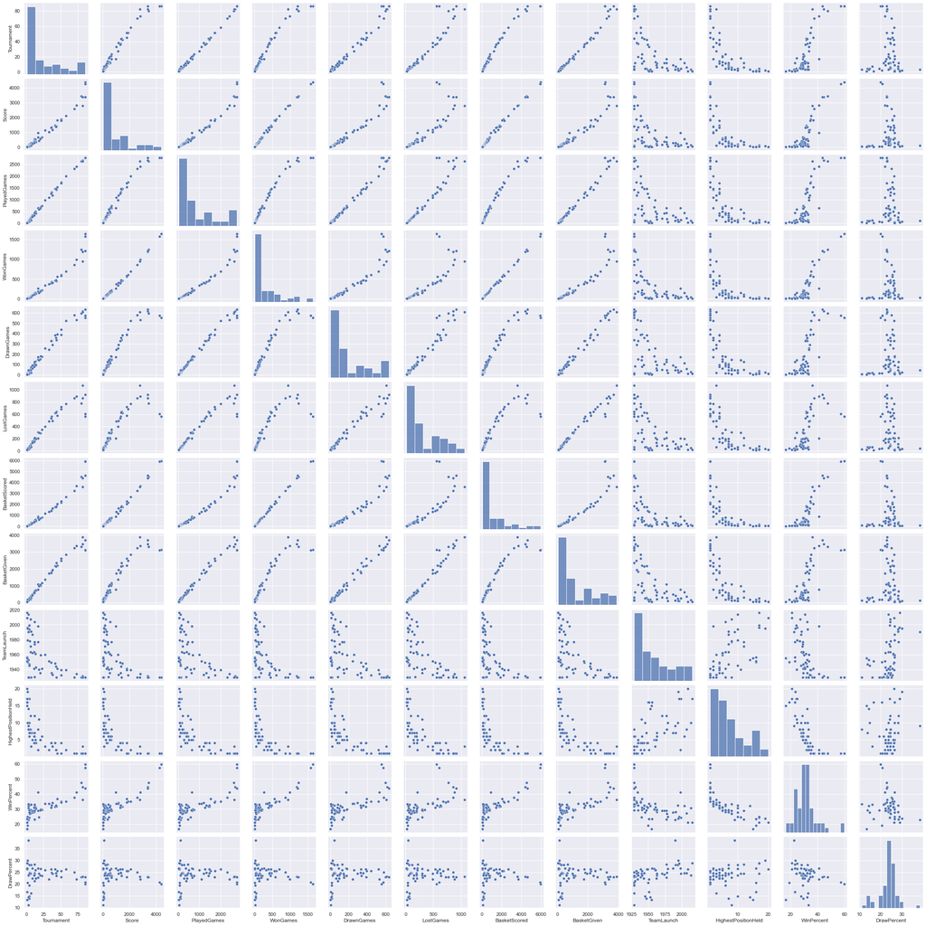

```python
sns.pairplot(basket_data)
```

```python
cor =basket_data.corr()
cor #Correlation between variables
```

|  | Tournament | Score | PlayedGames | WonGames | DrawnGames | LostGames | BasketScored | BasketGiven | TeamLaunch | HighestPositionHeld | WinPercent | DrawPercent |
| --- | --- | --- | --- | --- | --- | --- | --- | --- | --- | --- | --- | --- |
| Tournament | 1.000000 | 0.981258 | 0.998683 | 0.971749 | 0.989295 | 0.949350 | 0.974867 | 0.987781 | -0.599166 | -0.708002 | 0.819545 | -0.003360 |
| Score | 0.981258 | 1.000000 | 0.979687 | 0.997232 | 0.958090 | 0.878780 | 0.996634 | 0.943801 | -0.538542 | -0.669215 | 0.877374 | -0.014233 |
| PlayedGames | 0.998683 | 0.979687 | 1.000000 | 0.967486 | 0.993972 | 0.955925 | 0.969970 | 0.990020 | -0.581243 | -0.711065 | 0.813167 | 0.019754 |
| WonGames | 0.971749 | 0.997232 | 0.967486 | 1.000000 | 0.939416 | 0.851436 | 0.999312 | 0.925745 | -0.540421 | -0.647819 | 0.884266 | -0.038627 |
| DrawnGames | 0.989295 | 0.958090 | 0.993972 | 0.939416 | 1.000000 | 0.972786 | 0.942234 | 0.992479 | -0.570175 | -0.720248 | 0.774409 | 0.068343 |
| LostGames | 0.949350 | 0.878780 | 0.955925 | 0.851436 | 0.972786 | 1.000000 | 0.857843 | 0.985041 | -0.591571 | -0.726172 | 0.665352 | 0.065677 |
| BasketScored | 0.974867 | 0.996634 | 0.969970 | 0.999312 | 0.942234 | 0.857843 | 1.000000 | 0.931079 | -0.550150 | -0.648672 | 0.879110 | -0.044405 |
| BasketGiven | 0.987781 | 0.943801 | 0.990020 | 0.925745 | 0.992479 | 0.985041 | 0.931079 | 1.000000 | -0.608902 | -0.727323 | 0.757267 | 0.021462 |
| TeamLaunch | -0.599166 | -0.538542 | -0.581243 | -0.540421 | -0.570175 | -0.591571 | -0.550150 | -0.608902 | 1.000000 | 0.599679 | -0.491244 | 0.478500 |
| HighestPositionHeld | -0.708002 | -0.669215 | -0.711065 | -0.647819 | -0.720248 | -0.726172 | -0.648672 | -0.727323 | 0.599679 | 1.000000 | -0.737345 | 0.047801 |
| WinPercent | 0.819545 | 0.877374 | 0.813167 | 0.884266 | 0.774409 | 0.665352 | 0.879110 | 0.757267 | -0.491244 | -0.737345 | 1.000000 | -0.150212 |
| DrawPercent | -0.003360 | -0.014233 | 0.019754 | -0.038627 | 0.068343 | 0.065677 | -0.044405 | 0.021462 | 0.478500 | 0.047801 | -0.150212 | 1.000000 |

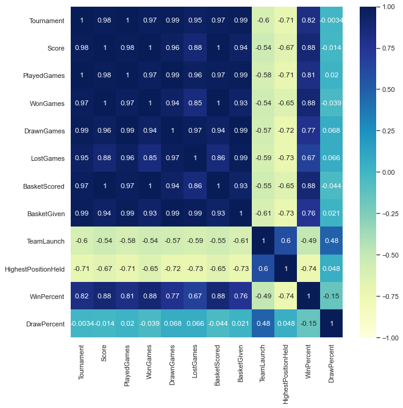

```python
plt.figure(figsize=(10,10))
sns.heatmap(cor,annot=True,cmap='YlGnBu',vmin=-1,vmax=1)
#Heatmap for visualizing the correlation
```

**From above three methods we check for the correlation between the variables**  
**We can see a good correlation between WinPercent and Score,BasketScored**

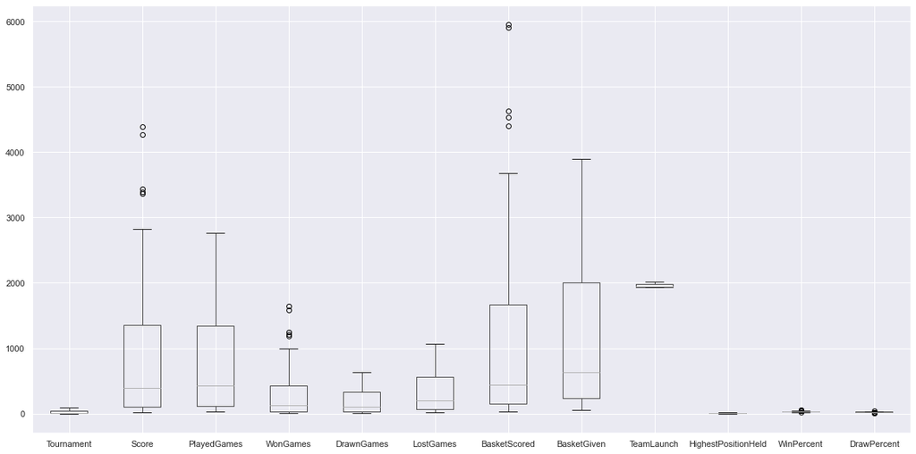

```python
plt.figure(figsize=(20,10))
basket_data.boxplot()
```

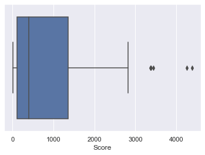

```python
sns.boxplot(x=basket_data['Score']);
```

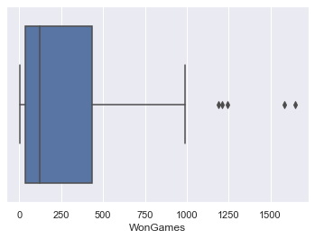

```python
sns.boxplot(x=basket_data['WonGames']);
```

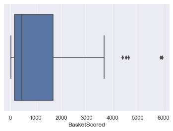

```python
sns.boxplot(x=basket_data['BasketScored']);
```

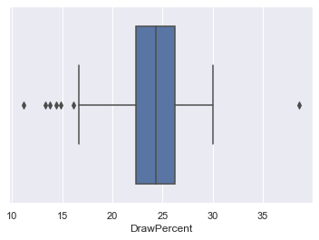

```python
sns.boxplot(x=basket_data['DrawPercent']);
#DrawPercent wil show outliers since it is a derived value
```

**The above codes checks for outliers, here we ignore the outliers because they are not caused due to any erro data etc**

**The objective stated that some of the older teams are already in contract with competitors. So lets look whether there is any relation with Year of Launch and the performance**

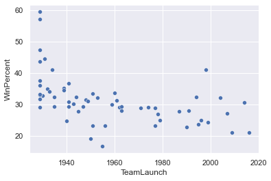

```python
sns.scatterplot(x='TeamLaunch',y='WinPercent',data=basket_data);
```

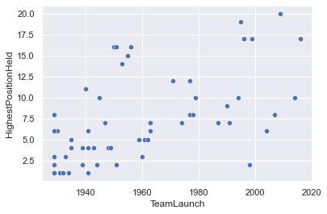

```python
sns.scatterplot(x='TeamLaunch',y='HighestPositionHeld',data=basket_data);
```

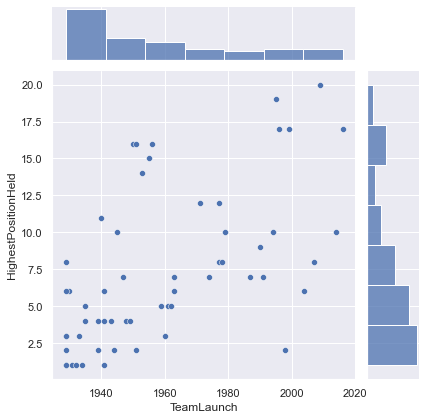

```python
sns.jointplot(x='TeamLaunch',y='HighestPositionHeld',data=basket_data);
```

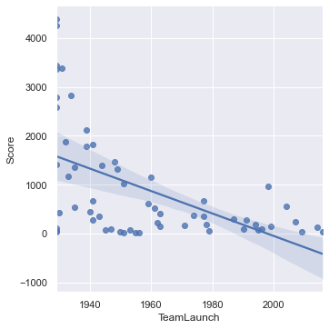

```python
sns.lmplot(x='TeamLaunch',y='Score',data=basket_data)
```

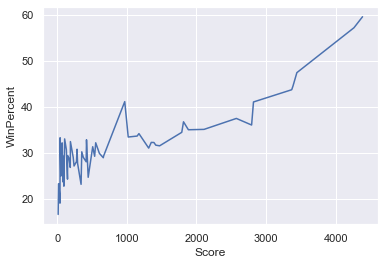

```python
sns.lineplot(x='Score',y='WinPercent',data=basket_data);
```

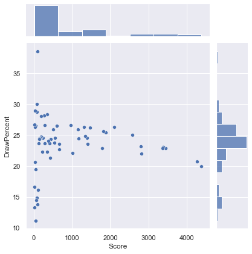

```python
sns.jointplot(x='Score',y='DrawPercent',data=basket_data);
```

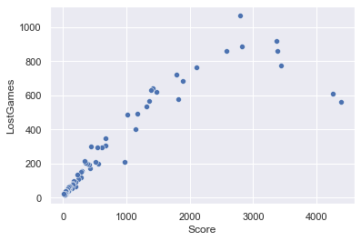

```python
sns.scatterplot(x='Score',y='LostGames',data=basket_data)
```

**From above we can say that team score can affect the performance or can take as a winning factor**

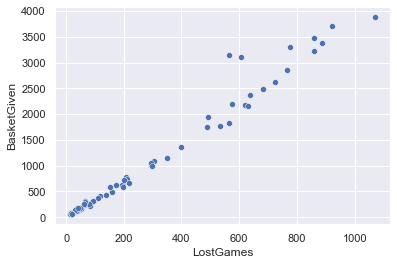

```python
sns.scatterplot(y='BasketGiven',x='LostGames',data=basket_data)
```

**From above it is evident that number of basket given affects the number LostGames**

**We need to recommend best teams to invest**  
**Teams with highest winning chance alone cannot determine our recommendation. First we have to find the teams with highest winning chance.**

```python
win_chance_df = basket_data.sort_values(by='WinPercent',ascending=False)
win_chance_df
```

|  | Team | Tournament | Score | PlayedGames | WonGames | DrawnGames | LostGames | BasketScored | BasketGiven | TeamLaunch | HighestPositionHeld | WinPercent | DrawPercent |
| --- | --- | --- | --- | --- | --- | --- | --- | --- | --- | --- | --- | --- | --- |
| 0 | Team 1 | 86 | 4385 | 2762 | 1647 | 552 | 563 | 5947 | 3140 | 1929 | 1 | 59.63 | 19.99 |
| 1 | Team 2 | 86 | 4262 | 2762 | 1581 | 573 | 608 | 5900 | 3114 | 1929 | 1 | 57.24 | 20.75 |
| 2 | Team 3 | 80 | 3442 | 2614 | 1241 | 598 | 775 | 4534 | 3309 | 1929 | 1 | 47.48 | 22.88 |
| 3 | Team 4 | 82 | 3386 | 2664 | 1187 | 616 | 861 | 4398 | 3469 | 1931 | 1 | 44.56 | 23.12 |
| 4 | Team 5 | 86 | 3368 | 2762 | 1209 | 633 | 920 | 4631 | 3700 | 1929 | 1 | 43.77 | 22.92 |
| 20 | Team 21 | 17 | 970 | 646 | 266 | 172 | 208 | 892 | 789 | 1998 | 2 | 41.18 | 26.63 |
| 5 | Team 6 | 73 | 2819 | 2408 | 990 | 531 | 887 | 3680 | 3373 | 1934 | 1 | 41.11 | 22.05 |
| 7 | Team 8 | 70 | 2573 | 2302 | 864 | 577 | 861 | 3228 | 3230 | 1929 | 1 | 37.53 | 25.07 |
| 10 | Team 11 | 45 | 1814 | 1530 | 563 | 392 | 575 | 2052 | 2188 | 1941 | 1 | 36.80 | 25.62 |
| 6 | Team 7 | 82 | 2792 | 2626 | 948 | 608 | 1070 | 3609 | 3889 | 1929 | 3 | 36.10 | 23.15 |
| 8 | Team 9 | 58 | 2109 | 1986 | 698 | 522 | 766 | 2683 | 2847 | 1939 | 2 | 35.15 | 26.28 |
| 9 | Team 10 | 51 | 1884 | 1728 | 606 | 440 | 682 | 2159 | 2492 | 1932 | 1 | 35.07 | 25.46 |
| 11 | Team 12 | 51 | 1789 | 1698 | 586 | 389 | 723 | 2278 | 2624 | 1939 | 4 | 34.51 | 22.91 |
| 17 | Team 18 | 38 | 1174 | 1192 | 408 | 292 | 492 | 1642 | 1951 | 1933 | 3 | 34.23 | 24.50 |
| 18 | Team 19 | 27 | 1148 | 988 | 333 | 256 | 399 | 1182 | 1371 | 1960 | 3 | 33.70 | 25.91 |
| 19 | Team 20 | 33 | 1020 | 1096 | 367 | 242 | 487 | 1347 | 1746 | 1951 | 2 | 33.49 | 22.08 |
| 53 | Team 54 | 3 | 42 | 54 | 18 | 6 | 30 | 97 | 131 | 1929 | 8 | 33.33 | 11.11 |
| 44 | Team 45 | 7 | 107 | 130 | 43 | 21 | 66 | 227 | 308 | 1929 | 3 | 33.08 | 16.15 |
| 28 | Team 29 | 12 | 421 | 380 | 125 | 81 | 174 | 458 | 623 | 1930 | 6 | 32.89 | 21.32 |
| 38 | Team 39 | 4 | 190 | 160 | 52 | 45 | 63 | 199 | 241 | 1994 | 10 | 32.50 | 28.12 |
| 15 | Team 16 | 37 | 1351 | 1318 | 426 | 327 | 565 | 1500 | 1834 | 1935 | 4 | 32.32 | 24.81 |
| 14 | Team 15 | 43 | 1389 | 1458 | 471 | 358 | 629 | 1753 | 2152 | 1944 | 2 | 32.30 | 24.55 |
| 24 | Team 25 | 12 | 553 | 456 | 147 | 112 | 197 | 520 | 633 | 2004 | 6 | 32.24 | 24.56 |
| 50 | Team 51 | 3 | 71 | 90 | 29 | 13 | 48 | 121 | 183 | 1953 | 14 | 32.22 | 14.44 |
| 13 | Team 14 | 44 | 1416 | 1428 | 453 | 336 | 639 | 1843 | 2368 | 1929 | 2 | 31.72 | 23.53 |
| 12 | Team 13 | 42 | 1471 | 1466 | 463 | 384 | 619 | 1767 | 2180 | 1948 | 4 | 31.58 | 26.19 |
| 26 | Team 27 | 13 | 510 | 494 | 155 | 128 | 211 | 619 | 744 | 1961 | 5 | 31.38 | 25.91 |
| 16 | Team 17 | 36 | 1314 | 1255 | 390 | 330 | 535 | 1421 | 1763 | 1949 | 4 | 31.08 | 26.29 |
| 34 | Team 35 | 11 | 285 | 334 | 103 | 79 | 152 | 419 | 588 | 1941 | 4 | 30.84 | 23.65 |
| 43 | Team 44 | 3 | 132 | 114 | 35 | 27 | 52 | 139 | 167 | 2014 | 10 | 30.70 | 23.68 |
| 31 | Team 32 | 14 | 353 | 426 | 129 | 95 | 202 | 492 | 720 | 1943 | 4 | 30.28 | 22.30 |
| 23 | Team 24 | 21 | 606 | 678 | 203 | 180 | 295 | 750 | 1022 | 1959 | 5 | 29.94 | 26.55 |
| 41 | Team 42 | 6 | 150 | 180 | 53 | 44 | 83 | 165 | 221 | 1963 | 7 | 29.44 | 24.44 |
| 21 | Team 22 | 23 | 667 | 742 | 218 | 175 | 349 | 819 | 1157 | 1941 | 6 | 29.38 | 23.58 |
| 46 | Team 47 | 4 | 91 | 116 | 34 | 16 | 66 | 181 | 295 | 1947 | 7 | 29.31 | 13.79 |
| 25 | Team 26 | 20 | 538 | 628 | 184 | 149 | 295 | 716 | 1050 | 1935 | 5 | 29.30 | 23.73 |
| 51 | Team 52 | 4 | 56 | 72 | 21 | 14 | 37 | 153 | 184 | 1929 | 6 | 29.17 | 19.44 |
| 30 | Team 31 | 12 | 375 | 423 | 123 | 102 | 198 | 422 | 581 | 1974 | 7 | 29.08 | 24.11 |
| 37 | Team 38 | 9 | 230 | 282 | 82 | 63 | 137 | 285 | 430 | 1962 | 5 | 29.08 | 22.34 |
| 22 | Team 23 | 17 | 662 | 652 | 189 | 148 | 305 | 760 | 1088 | 1977 | 8 | 28.99 | 22.70 |
| 40 | Team 41 | 6 | 168 | 204 | 59 | 50 | 95 | 216 | 310 | 1971 | 12 | 28.92 | 24.51 |
| 35 | Team 36 | 7 | 277 | 270 | 76 | 76 | 118 | 320 | 410 | 1991 | 7 | 28.15 | 28.15 |
| 29 | Team 30 | 11 | 416 | 402 | 113 | 95 | 194 | 430 | 632 | 1963 | 6 | 28.11 | 23.63 |
| 49 | Team 50 | 4 | 76 | 108 | 30 | 16 | 62 | 145 | 252 | 1945 | 10 | 27.78 | 14.81 |
| 33 | Team 34 | 9 | 293 | 346 | 96 | 92 | 158 | 291 | 489 | 1987 | 7 | 27.75 | 26.59 |
| 36 | Team 37 | 6 | 242 | 228 | 62 | 56 | 110 | 244 | 366 | 2007 | 8 | 27.19 | 24.56 |
| 39 | Team 40 | 5 | 188 | 186 | 50 | 46 | 90 | 202 | 296 | 1978 | 8 | 26.88 | 24.73 |
| 47 | Team 48 | 2 | 83 | 80 | 20 | 23 | 37 | 62 | 117 | 1996 | 17 | 25.00 | 28.75 |
| 52 | Team 53 | 2 | 52 | 68 | 17 | 18 | 33 | 71 | 116 | 1979 | 10 | 25.00 | 26.47 |
| 27 | Team 28 | 18 | 445 | 586 | 145 | 143 | 298 | 607 | 992 | 1940 | 11 | 24.74 | 24.40 |
| 42 | Team 43 | 4 | 148 | 152 | 37 | 37 | 78 | 155 | 253 | 1999 | 17 | 24.34 | 24.34 |
| 48 | Team 49 | 2 | 81 | 80 | 19 | 24 | 37 | 70 | 115 | 1995 | 19 | 23.75 | 30.00 |
| 57 | Team 58 | 1 | 22 | 30 | 7 | 8 | 15 | 37 | 57 | 1956 | 16 | 23.33 | 26.67 |
| 58 | Team 59 | 1 | 19 | 30 | 7 | 5 | 18 | 51 | 85 | 1951 | 16 | 23.33 | 16.67 |
| 32 | Team 33 | 12 | 343 | 448 | 104 | 127 | 217 | 393 | 662 | 1977 | 12 | 23.21 | 28.35 |
| 45 | Team 46 | 3 | 96 | 114 | 26 | 44 | 44 | 101 | 139 | 1990 | 9 | 22.81 | 38.60 |
| 55 | Team 56 | 1 | 35 | 38 | 8 | 11 | 19 | 36 | 55 | 2016 | 17 | 21.05 | 28.95 |
| 56 | Team 57 | 1 | 34 | 38 | 8 | 10 | 20 | 38 | 66 | 2009 | 20 | 21.05 | 26.32 |
| 54 | Team 55 | 2 | 40 | 68 | 13 | 14 | 41 | 70 | 182 | 1950 | 16 | 19.12 | 20.59 |
| 59 | Team 60 | 1 | 14 | 30 | 5 | 4 | 21 | 34 | 65 | 1955 | 15 | 16.67 | 13.33 |

```python
basket_data.groupby('TeamLaunch').mean()['WinPercent'].sort_values(ascending=False)
```

```
TeamLaunch
1931    44.560
1998    41.180
1934    41.110
1929    40.905
1932    35.070
1939    34.830
1933    34.230
1960    33.700
1930    32.890
1994    32.500
1941    32.340
1944    32.300
2004    32.240
1953    32.220
```

[output cut: 31 more lines]

**What we have done is: we took mean of the win percentage of teams that were launched on same year, this is done because our competitors are in contract with old teams. So now if our intention is to choose newer teams we can select corresponding team with higher winning chance.**

**I Would recommend teams that are launched on year 1998,they also have a higher chance of winning**

**I would suggest the management team to collect data more precisely on attributes such as TournamentChampions, Runnersup**  
**More Categorical data could have been included so that more accurate analysis be made.**  
**The data collected on TeamLaunch could be made more meaningfull**

## Part Three - PROJECT BASED

**• DOMAIN :** Startup ecosystem

**• CONTEXT :** Company X is a EU online publisher focusing on the startups industry. The company specifically reports on the business related to technology news, analysis of emerging trends and profiling of new tech businesses and products. Their event i.e. Startup Battlefield is the world’s pre-eminent startup competition. Startup Battlefield features 15-30 top early stage startups pitching top judges in front of a vast live audience, present in person and online.

**• DATA DESCRIPTION:** CompanyX_EU.csv - Each row in the dataset is a Start-up company and the columns describe the company.

**ATTRIBUTE INFORMATION:**

**1. Startup:** Name of the company

**2. Product:** Actual product

**3. Funding:** Funds raised by the company in USD

**4. Event:** The event the company participated in

**5. Result:** Described by Contestant, Finalist, Audience choice, Winner or Runner up

**6. OperatingState:** Current status of the company, Operating ,Closed, Acquired or IPO

*Dataset has been downloaded from the internet. All the credit for the dataset goes to the original creator of the data.

**• PROJECT OBJECTIVE:** Analyse the data of the various companies from the given dataset and perform the tasks that are specified in the below steps. Draw insights from the various attributes that are present in the dataset, plot distributions, state hypotheses and draw conclusions from the dataset.

**Steps and tasks:**

**1. Data warehouse:**

```
• Read the CSV file.
```

**2. Data exploration:**

```
• Check the datatypes of each attribute.
• Check for null values in the attributes.
```

**3. Data preprocessing & visualisation:**

```
• Drop the null values.
• Convert the ‘Funding’ features to a numerical value.
• Plot box plot for funds in million.
• Get the lower fence from the box plot.
• Check number of outliers greater than upper fence.
• Drop the values that are greater than upper fence.
• Plot the box plot after dropping the values.
• Check frequency of the OperatingState features classes.
• Plot a distribution plot for Funds in million.
• Plot distribution plots for companies still operating and companies that closed.
```

**4. Statistical analysis:**

```
• Is there any significant difference between Funds raised by companies that are still operating vs companies that closed down?
    Write the null hypothesis and alternative hypothesis.
    Test for significance and conclusion

• Make a copy of the original data frame.

• Check frequency distribution of Result variable.

• Calculate percentage of winners that are still operating and percentage of contestants that are still operating

• Write your hypothesis comparing the proportion of companies that are operating between winners and contestants:
     Write the null hypothesis and alternative hypothesis.
     Test for significance and conclusion

• Check distribution of the Event variable.

• Select only the Event that has disrupt keyword from 2013 onwards.

• Write and perform your hypothesis along with significance test comparing the funds raised by companies across NY, SF and EU events from 2013 onwards.

• Plot the distribution plot comparing the 3 city events.
```

**5. Write your observations on improvements or suggestions on quality, quantity, variety, velocity, veracity etc. on the data points collected to perform a better data analysis.**

```python
company_data= pd.read_csv('CompanyX_EU.csv')
```

```python
print(company_data.shape)
print(company_data.size)
```

```
(662, 6)
3972
```

**File has 662 rows and 6 columns**

```python
company_data.head(10)
```

|  | Startup | Product | Funding | Event | Result | OperatingState |
| --- | --- | --- | --- | --- | --- | --- |
| 0 | 2600Hz | 2600hz.com | NaN | Disrupt SF 2013 | Contestant | Operating |
| 1 | 3DLT | 3dlt.com | $630K | Disrupt NYC 2013 | Contestant | Closed |
| 2 | 3DPrinterOS | 3dprinteros.com | NaN | Disrupt SF 2016 | Contestant | Operating |
| 3 | 3Dprintler | 3dprintler.com | $1M | Disrupt NY 2016 | Audience choice | Operating |
| 4 | 42 Technologies | 42technologies.com | NaN | Disrupt NYC 2013 | Contestant | Operating |
| 5 | 5to1 | 5to1.com | $19.3M | TC50 2009 | Contestant | Acquired |
| 6 | 8 Securities | 8securities.com | $29M | Disrupt Beijing 2011 | Finalist | Operating |
| 7 | 8020 Media | 8020media.com | NaN | TC40 2007 | Contestant | Operating |
| 8 | About Last Night | aboutlastnight.net | NaN | Disrupt NYC 2012 | Contestant | Operating |
| 9 | Adgregate Markets | adgregate.com | NaN | TC50 2008 | Contestant | Operating |

```python
company_data.tail(10)
```

|  | Startup | Product | Funding | Event | Result | OperatingState |
| --- | --- | --- | --- | --- | --- | --- |
| 652 | Yuwan | iyuwan.cn | NaN | Disrupt Beijing 2011 | Contestant | Closed |
| 653 | ZAP! | zapreklam.com/ | NaN | Disrupt EU 2014 | Audience choice | Operating |
| 654 | ZEFR | zefr.com | $62.1M | Disrupt NYC 2010 | Contestant | Operating |
| 655 | Zello | zello.com | NaN | TC40 2007 | Contestant | Operating |
| 656 | Zenefits | zenefits.com | $583.6M | Disrupt NYC 2013 | Finalist | Operating |
| 657 | Zivity | zivity.com | $8M | TC40 2007 | Contestant | Operating |
| 658 | Zmorph | zmorph3d.com | $1M | - | Audience choice | Operating |
| 659 | Zocdoc | zocdoc.com | $223M | TC40 2007 | Contestant | Operating |
| 660 | Zula | zulaapp.com | $3.4M | Disrupt SF 2013 | Audience choice | Operating |
| 661 | Zumper | zumper.com | $31.5M | Disrupt SF 2012 | Finalist | Operating |

```python
company_data.dtypes
```

```
Startup           object
Product           object
Funding           object
Event             object
Result            object
OperatingState    object
dtype: object
```

```python
company_data.info()
```

```
<class 'pandas.core.frame.DataFrame'>
RangeIndex: 662 entries, 0 to 661
Data columns (total 6 columns):
 #   Column          Non-Null Count  Dtype
---  ------          --------------  -----
 0   Startup         662 non-null    object
 1   Product         656 non-null    object
 2   Funding         448 non-null    object
 3   Event           662 non-null    object
 4   Result          662 non-null    object
 5   OperatingState  662 non-null    object
dtypes: object(6)
memory usage: 31.2+ KB
```

```python
company_data.isna().sum()
```

```
Startup             0
Product             6
Funding           214
Event               0
Result              0
OperatingState      0
dtype: int64
```

**From the above codes we determine there are null values and we summarised the number of null values in each attribute**

```python
copy1_company_data = company_data.dropna().copy() #dropping and copying to a new dataframe, this will not affect the original dataframe
```

```python
print(copy1_company_data.shape)
print(copy1_company_data.size)
```

```
(446, 6)
2676
```

```python
copy1_company_data.info()
```

```
<class 'pandas.core.frame.DataFrame'>
Int64Index: 446 entries, 1 to 661
Data columns (total 6 columns):
 #   Column          Non-Null Count  Dtype
---  ------          --------------  -----
 0   Startup         446 non-null    object
 1   Product         446 non-null    object
 2   Funding         446 non-null    object
 3   Event           446 non-null    object
 4   Result          446 non-null    object
 5   OperatingState  446 non-null    object
dtypes: object(6)
memory usage: 24.4+ KB
```

```python
copy1_company_data.isna().sum()
```

```
Startup           0
Product           0
Funding           0
Event             0
Result            0
OperatingState    0
dtype: int64
```

**We removed the rows having null values and stored in a new dataframe. We checked for the change in dimensions and for the null values of new dataframe after droping.**

```python
#The attribute Funding is in object type even though it should be a integer values and the values in the attribute are not
#in same format which makes it difficult for futher analysis.
#Lets check some values of Funds
copy1_company_data.Funding.head(10)
```

```
1      $630K
3        $1M
5     $19.3M
6       $29M
10     $1.8M
11       $1M
13       $1M
14     $750K
15    $17.9K
16    $11.6M
Name: Funding, dtype: object
```

```python
copy1_company_data.Funding.sample(5)
```

```
659      $223M
113    $182.1M
55        $20K
209      $103M
295        $3M
Name: Funding, dtype: object
```

**Since the data are in different format we need to convert it into a single format 'Funds in Millions'**

```python
def inMillion(x):
    if x[-1]=='K':
        return float(x[1:-1])/1000
    elif x[-1]=='B':
        return float(x[1:-1])*1000
    else:
        return float(x[1:-1])
#This is a function to filter out the different abbreviations and to convert the value to Millions.
```

```python
copy1_company_data.loc[:,'Funds_in_Millions']= copy1_company_data['Funding'].apply(lambda x:inMillion(x))
```

**Here we took each row of attribute 'Funding' and passed as argument to our function inMillion() using our inline function lambda.**  
**We could also do the same with inline function alone. The function takes the string value and check for its abbreviations if it is in 'K' (ie 1000) we divide it with 1000,if it is in 'B' we multiply with 1000 to change the value to Millions and convert it to float.**  
**If the abbreviation is 'M' we change it from string to float. In these filtering we also remove the $ symbol from the value.**  
**We stored this Filtered values to a new attribute 'Funds_in_Millions'**

```python
copy1_company_data.head(10)
```

|  | Startup | Product | Funding | Event | Result | OperatingState | Funds_in_Millions |
| --- | --- | --- | --- | --- | --- | --- | --- |
| 1 | 3DLT | 3dlt.com | $630K | Disrupt NYC 2013 | Contestant | Closed | 0.6300 |
| 3 | 3Dprintler | 3dprintler.com | $1M | Disrupt NY 2016 | Audience choice | Operating | 1.0000 |
| 5 | 5to1 | 5to1.com | $19.3M | TC50 2009 | Contestant | Acquired | 19.3000 |
| 6 | 8 Securities | 8securities.com | $29M | Disrupt Beijing 2011 | Finalist | Operating | 29.0000 |
| 10 | AdhereTech | adheretech.com | $1.8M | Hardware Battlefield 2014 | Contestant | Operating | 1.8000 |
| 11 | AdRocket | adrocket.com | $1M | TC50 2008 | Contestant | Closed | 1.0000 |
| 13 | Agrilyst | agrilyst.com | $1M | Disrupt SF 2015 | Winner | Operating | 1.0000 |
| 14 | Aiden | aiden.ai | $750K | Disrupt London 2016 | Contestant | Operating | 0.7500 |
| 15 | AirBoxLab | foobot.io | $17.9K | Hardware Battlefield 2014 | Contestant | Operating | 0.0179 |
| 16 | Aircall | aircall.io | $11.6M | Disrupt SF 2015 | Contestant | Operating | 11.6000 |

**From above we confirm we created a new column with Funding converted to millions**

```python
copy1_company_data.dtypes
#The data type of new column is float
```

```
Startup               object
Product               object
Funding               object
Event                 object
Result                object
OperatingState        object
Funds_in_Millions    float64
dtype: object
```

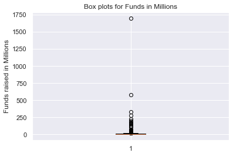

```python
plt.boxplot(copy1_company_data.Funds_in_Millions)
plt.title("Box plots for Funds in Millions")
plt.ylabel('Funds raised in Millions')
plt.show()
```

**There are Outliers in data so we need to remove it**

```python
copy1_company_data.Funds_in_Millions.describe()
```

```
count     446.000000
mean       17.241489
std        90.483710
min         0.005000
25%         0.745250
50%         2.200000
75%         9.475000
max      1700.000000
Name: Funds_in_Millions, dtype: float64
```

```python
print(copy1_company_data.Funds_in_Millions.quantile([0.25,0.5,0.75]))
Q1 = copy1_company_data.Funds_in_Millions.quantile(0.25) #First Quartile
Q3 = copy1_company_data.Funds_in_Millions.quantile(0.75) #Third Quartile
```

```
0.25    0.74525
0.50    2.20000
0.75    9.47500
Name: Funds_in_Millions, dtype: float64
```

```python
IQR = Q3-Q1
#IQR = Q3-Q1
print(IQR) #Inter Quartile Range
```

```
8.72975
```

```python
upper_fence = Q3 + IQR*1.5 #Upper Fence
print(upper_fence)
```

```
22.569625
```

```python
lower_fence = Q1 - (IQR*1.5) #Lower Fence
print(lower_fence)
```

```
-12.349374999999998
```

**Since we got the upper_fence and lower_fence we can find the outliers data**

```python
outliers_data = copy1_company_data[copy1_company_data['Funds_in_Millions']>upper_fence]

print('Number of Outliers greater than upper fence = %d'%len(outliers_data))
outliers_data
```

```
Number of Outliers greater than upper fence = 60
```

|  | Startup | Product | Funding | Event | Result | OperatingState | Funds_in_Millions |
| --- | --- | --- | --- | --- | --- | --- | --- |
| 6 | 8 Securities | 8securities.com | $29M | Disrupt Beijing 2011 | Finalist | Operating | 29.0 |
| 31 | Anyclip | anyclip.com | $24M | TC50 2009 | Finalist | Operating | 24.0 |
| 40 | Artsy | artsy.net | $50.9M | Disrupt NYC 2010 | Contestant | Operating | 50.9 |
| 49 | Badgeville | badgeville.com | $40M | Disrupt SF 2010 | Finalist | Acquired | 40.0 |
| 56 | Betterment | betterment.com | $205M | Disrupt NYC 2010 | Finalist | Operating | 205.0 |
| 108 | Clickable | clickable.com | $32.5M | TC40 2007 | Finalist | Acquired | 32.5 |
| 113 | Cloudflare | cloudflare.com | $182.1M | Disrupt SF 2010 | Runner up | Operating | 182.1 |
| 128 | Credit Sesame | creditsesame.com | $35.4M | Disrupt SF 2010 | Contestant | Operating | 35.4 |
| 130 | CrowdFlower Inc. | crowdflower.com | $38M | TC50 2009 | Contestant | Operating | 38.0 |
| 132 | Cubic Telecom | cubictelecom.com | $37.1M | TC40 2007 | Contestant | Operating | 37.1 |
| 138 | DataSift | datasift.com | $72M | Disrupt SF 2010 | Finalist | Operating | 72.0 |
| 139 | DataXu | dataxu.com | $64M | TC50 2009 | Contestant | Operating | 64.0 |
| 154 | Dropbox | dropbox.com | $1.7B | TC50 2008 | Contestant | Operating | 1700.0 |
| 166 | Enigma | enigma.io | $34.6M | Disrupt NYC 2013 | Winner | Operating | 34.6 |
| 172 | EverythingMe | everything.me | $35.5M | Disrupt NYC 2011 | Contestant | Closed | 35.5 |
| 179 | Famo.us | famo.us | $30.1M | Disrupt SF 2012 | Contestant | Operating | 30.1 |
| 180 | Farmigo | farmigo.com | $26M | Disrupt SF 2011 | Finalist | Operating | 26.0 |
| 188 | Fitbit | fitbit.com | $66M | TC50 2008 | Finalist | Ipo | 66.0 |
| 191 | Flock | flock.com | $28.3M | TC40 2007 | Contestant | Acquired | 28.3 |
| 209 | Getaround | getaround.com | $103M | Disrupt NYC 2011 | Winner | Operating | 103.0 |
| 213 | Gild | gild.com | $25.9M | Disrupt SF 2010 | Contestant | Acquired | 25.9 |
| 215 | Glide | glide.me | $36.5M | Disrupt NYC 2013 | Audience choice | Operating | 36.5 |
| 225 | Grockit | grockit.com | $44.7M | TC50 2008 | Finalist | Acquired | 44.7 |
| 231 | HackerRank | hackerrank.com | $24.2M | Disrupt SF 2012 | Contestant | Operating | 24.2 |
| 271 | Ionic Security | ionicsecurity.com | $122.4M | Disrupt SF 2012 | Contestant | Operating | 122.4 |
| 276 | IZEA | izea.com | $34.9M | Disrupt NYC 2010 | Contestant | Ipo | 34.9 |
| 279 | Jiff | jiff.com | $67.8M | Disrupt SF 2011 | Contestant | Acquired | 67.8 |
| 282 | Kaltura | kaltura.com | $166.1M | TC40 2007 | Audience choice | Operating | 166.1 |
| 302 | Layer | layer.com | $42.1M | Disrupt SF 2013 | Winner | Operating | 42.1 |
| 305 | LearnVest | learnvest.com | $69M | TC50 2009 | Contestant | Acquired | 69.0 |
| 313 | LiveIntent | liveintent.com | $65.1M | Disrupt NYC 2010 | Audience choice | Operating | 65.1 |
| 325 | Lystable | lystable.com | $25.1M | Disrupt London 2015 | Finalist | Operating | 25.1 |
| 346 | Mint | mint.com | $31.8M | TC40 2007 | Winner | Acquired | 31.8 |
| 389 | OrderWithMe | orderwithme.com | $37M | Disrupt Beijing 2011 | Winner | Operating | 37.0 |
| 393 | Osmo | playosmo.com | $38.5M | Disrupt SF 2013 | Contestant | Operating | 38.5 |
| 394 | Ossia | ossia.com | $25.5M | Disrupt SF 2013 | Runner up | Operating | 25.5 |
| 398 | Owlet Baby Care | owletcare.com | $24M | Hardware Battlefield 2014 | Runner up | Operating | 24.0 |
| 427 | Postmates | postmates.com | $278M | Disrupt SF 2011 | Contestant | Operating | 278.0 |
| 432 | Prism Skylabs | prism.com | $24M | Disrupt SF 2011 | Runner up | Operating | 24.0 |
| 435 | PubMatic | pubmatic.com | $63M | TC40 2007 | Contestant | Operating | 63.0 |
| 460 | Roadie | roadie.com | $25M | Disrupt NYC 2014 | Audience choice | Operating | 25.0 |
| 471 | SeatGeek | seatgeek.com | $160M | TC50 2009 | Contestant | Operating | 160.0 |
| 546 | StyleSeat | styleseat.com | $40M | Disrupt NYC 2011 | Contestant | Operating | 40.0 |
| 555 | Symphony Commerce | symphonycommerce.com | $47.4M | Disrupt NYC 2011 | Contestant | Operating | 47.4 |
| 560 | Talkdesk | talkdesk.com | $24.5M | Disrupt NYC 2012 | Contestant | Operating | 24.5 |
| 581 | TouchPal | touchpal.com | $25M | Disrupt Beijing 2011 | Finalist | Operating | 25.0 |
| 593 | TrueCar | truecar.com | $332.4M | TC50 2008 | Contestant | Ipo | 332.4 |
| 598 | UberConference | uberconference.com | $35M | Disrupt NYC 2012 | Winner | Operating | 35.0 |
| 606 | Upwork | upwork.com | $168.8M | TC50 2009 | Audience choice | Operating | 168.8 |
| 615 | VideoSurf | videosurf.com | $28M | TC50 2008 | Contestant | Acquired | 28.0 |
| 625 | Voxy | voxy.com | $30.8M | Disrupt SF 2010 | Contestant | Operating | 30.8 |
| 643 | Xobni | yahoo.com | $41.8M | TC40 2007 | Contestant | Acquired | 41.8 |
| 644 | Yammer | yammer.com | $142M | TC50 2008 | Winner | Acquired | 142.0 |
| 647 | Yext | yext.com | $117.8M | TC50 2009 | Contestant | Ipo | 117.8 |
| 649 | YouNow | younow.com | $26M | Disrupt SF 2011 | Contestant | Operating | 26.0 |
| 650 | YourMechanic | yourmechanic.com | $28M | Disrupt SF 2012 | Winner | Operating | 28.0 |
| 654 | ZEFR | zefr.com | $62.1M | Disrupt NYC 2010 | Contestant | Operating | 62.1 |
| 656 | Zenefits | zenefits.com | $583.6M | Disrupt NYC 2013 | Finalist | Operating | 583.6 |
| 659 | Zocdoc | zocdoc.com | $223M | TC40 2007 | Contestant | Operating | 223.0 |
| 661 | Zumper | zumper.com | $31.5M | Disrupt SF 2012 | Finalist | Operating | 31.5 |

**Now we can drop these 60 outlier data**

```python
copy1_company_data.drop(index=outliers_data.index,inplace=True) #Removed the outliers
```

**Now lets plot boxplot after removing outiers**

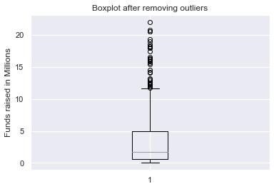

```python
plt.boxplot(copy1_company_data.Funds_in_Millions)
plt.title('Boxplot after removing outliers')
plt.ylabel('Funds raised in Millions')
plt.show()
```

```python
copy1_company_data.OperatingState.value_counts()
```

```
Operating    275
Closed        56
Acquired      55
Name: OperatingState, dtype: int64
```

**Frequency of OperatingState**

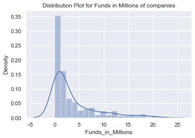

```python
sns.distplot(copy1_company_data.Funds_in_Millions)
plt.title('Distribution Plot for Funds in Millions of companies')
plt.show()
```

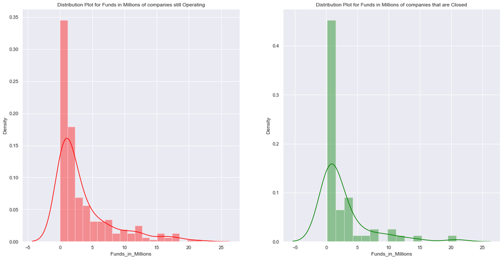

```python
fig,ax = plt.subplots(1,2)
fig.set_figheight(10)
fig.set_figwidth(20)

sns.distplot(copy1_company_data.loc[copy1_company_data.OperatingState == 'Operating','Funds_in_Millions'],ax=ax[0],color='Red')

sns.distplot(copy1_company_data.loc[copy1_company_data.OperatingState == 'Closed','Funds_in_Millions'],ax=ax[1],color='Green')
ax[0].set_title('Distribution Plot for Funds in Millions of companies still Operating')
ax[1].set_title('Distribution Plot for Funds in Millions of companies that are Closed')

plt.show()
```

**Above are the visualization of Funds in Millions, we also divided the funds based on the companies operating status**

**After visual analysis we check for statistical analysis**

**Null Hypothesis (Ho):** There is no significant difference between Funds raised by companies that are still operating and companies that are closed down.  
**Alternative Hypothesis (Ha):** There is significant difference between Funds raised by companies that are still operating and companies that are closed down.

**We can either use t-test or z-test for this, but since the sample is significantly large we use z-test**

```python
from statsmodels.stats.weightstats import ztest

s1 = copy1_company_data.loc[copy1_company_data.OperatingState == 'Operating','Funds_in_Millions']
s2 = copy1_company_data.loc[copy1_company_data.OperatingState == 'Closed','Funds_in_Millions']

t_stat,p_value = ztest(s1,s2)

if p_value <= 0.05: #We take the value of alpha as 0.05, ie significance level of 5%
    print(f'We reject the Null Hypothesis since p-value({round(p_value,2)}) is < alpha(0.05) ' )
else:
    print(f'We fail to reject the Null Hypothesis since p-value({round(p_value,2)}) is > alpha(0.05) ' )
```

```
We fail to reject the Null Hypothesis since p-value(0.19) is > alpha(0.05)
```

**Conclusion**  
**From above we can conclude that there is not enough evidence to prove there is significant difference between Funds raised by companies that are still operating and companies that are closed down.**

Make a copy of the original dataframe

```python
copy2_company_data = company_data.copy()
copy2_company_data.head()
```

|  | Startup | Product | Funding | Event | Result | OperatingState |
| --- | --- | --- | --- | --- | --- | --- |
| 0 | 2600Hz | 2600hz.com | NaN | Disrupt SF 2013 | Contestant | Operating |
| 1 | 3DLT | 3dlt.com | $630K | Disrupt NYC 2013 | Contestant | Closed |
| 2 | 3DPrinterOS | 3dprinteros.com | NaN | Disrupt SF 2016 | Contestant | Operating |
| 3 | 3Dprintler | 3dprintler.com | $1M | Disrupt NY 2016 | Audience choice | Operating |
| 4 | 42 Technologies | 42technologies.com | NaN | Disrupt NYC 2013 | Contestant | Operating |

```python
copy2_company_data.Result.value_counts()
```

```
Contestant         488
Finalist            84
Audience choice     41
Winner              26
Runner up           23
Name: Result, dtype: int64
```

**Frequency of Result Variable**

**Calculate percentage of winners that are still operating and percentage of contestants that are still operating**

```python
t_contestant = copy2_company_data.Result.value_counts()['Contestant']
t_winner = copy2_company_data.Result.value_counts()['Winner'] #We are taking companies who have actually won,ignoring runnersup,finalist etc
print('Total Winners = %d'%t_winner)
print('Total Contestant = %d'%t_contestant)
```

```
Total Winners = 26
Total Contestant = 488
```

```python
c_operating = copy2_company_data.OperatingState[copy2_company_data.Result == 'Contestant'].value_counts()['Operating']
w_operating = copy2_company_data.OperatingState[copy2_company_data.Result == 'Winner'].value_counts()['Operating']
print('Number of Operating companies that Won = %d'%w_operating)
print('Number of Operating companies that were Contestant = %d'%c_operating)
```

```
Number of Operating companies that Won = 19
Number of Operating companies that were Contestant = 332
```

```python
print('Percentage of Winners that are Still Operating = %2.2f%%'%((w_operating/t_winner)*100))
print('Percentage of Contestant that are Still Operating = %2.2f%%'%((c_operating/t_contestant)*100))
```

```
Percentage of Winners that are Still Operating = 73.08%
Percentage of Contestant that are Still Operating = 68.03%
```

**Write your hypothesis comparing the proportion of companies that are operating between winners and contestants:**

We will use z-test for proportions in this problem

**Null Hypothesis (Ho) :** There is equal proportion of companies that are operating between winners and contestants  
**Alternate Hypothesis (Ha) :** There is significant difference in proportion of companies that are operating between winners and contestants

```python
from statsmodels.stats.proportion import proportions_ztest

test_statistics,pvalue = proportions_ztest([c_operating,w_operating],[t_contestant,t_winner])

if pvalue <= 0.05: #We take the value of alpha as 0.05, ie significance level of 5%
    print(f'We reject the Null Hypothesis since p-value({round(pvalue,2)}) is < alpha(0.05) ' )
else:
    print(f'We fail to reject the Null Hypothesis since p-value({round(pvalue,2)}) is > alpha(0.05) ' )
```

```
We fail to reject the Null Hypothesis since p-value(0.59) is > alpha(0.05)
```

**Conclusion**  
**From the above we can conclude that just because a company Won it doesn't mean it is still operational or vice-versa**

Now we can check for the distribution of Event attribute

```python
copy1_company_data.Event.value_counts()
#Distribution of Event variable
```

```
TC50 2008                    25
TC40 2007                    22
Disrupt NY 2015              21
TC50 2009                    19
Disrupt SF 2013              19
Disrupt NYC 2013             19
Disrupt SF 2011              19
Disrupt SF 2014              19
Disrupt NYC 2012             19
Disrupt SF 2015              19
Disrupt SF 2016              17
Disrupt NY 2016              16
Disrupt SF 2012              15
Disrupt NYC 2011             15
Disrupt NYC 2014             15
Disrupt SF 2010              13
Hardware Battlefield 2016    12
Hardware Battlefield 2014    12
Disrupt London 2015          11
Disrupt NYC 2010             10
Disrupt EU 2014              10
Disrupt London 2016          10
Hardware Battlefield 2015    10
Disrupt EU 2013               9
-                             6
Disrupt Beijing 2011          4
Name: Event, dtype: int64
```

We want Events that has disrupt keyword from 2013 onwards

```python
d_event=copy1_company_data[copy1_company_data.Event.apply(lambda x: 'Disrupt' in x)]
d_event.Event.value_counts()
```

```
Disrupt NY 2015         21
Disrupt SF 2015         19
Disrupt SF 2014         19
Disrupt SF 2013         19
Disrupt SF 2011         19
Disrupt NYC 2013        19
Disrupt NYC 2012        19
Disrupt SF 2016         17
Disrupt NY 2016         16
Disrupt SF 2012         15
Disrupt NYC 2011        15
Disrupt NYC 2014        15
Disrupt SF 2010         13
Disrupt London 2015     11
Disrupt NYC 2010        10
Disrupt London 2016     10
Disrupt EU 2014         10
Disrupt EU 2013          9
Disrupt Beijing 2011     4
Name: Event, dtype: int64
```

Events having Disrupt keyword. Now we only want Events from 2013 onwards. So we have to filter out this data

```python
d_event_13 = d_event.Event[d_event.Event.apply(lambda x: int(x[-4:]) > 2012)]
d_event_13
```

```
1         Disrupt NYC 2013
3          Disrupt NY 2016
13         Disrupt SF 2015
14     Disrupt London 2016
16         Disrupt SF 2015
              ...
635        Disrupt NY 2015
641       Disrupt NYC 2013
642        Disrupt SF 2014
646    Disrupt London 2015
660        Disrupt SF 2013
Name: Event, Length: 185, dtype: object
```

```python
d_event_13.value_counts()
```

```
Disrupt NY 2015        21
Disrupt SF 2015        19
Disrupt NYC 2013       19
Disrupt SF 2013        19
Disrupt SF 2014        19
Disrupt SF 2016        17
Disrupt NY 2016        16
Disrupt NYC 2014       15
Disrupt London 2015    11
Disrupt London 2016    10
Disrupt EU 2014        10
Disrupt EU 2013         9
Name: Event, dtype: int64
```

**From the above we can confirm that we filtered out the events having Disrupt keyword and from 2013 onwards only.**

Write and perform your hypothesis along with significance test comparing the funds raised by companies across NY, SF and EU events from 2013 onwards

```python
NY_e = copy1_company_data.loc[d_event_13[d_event_13.apply(lambda x: 'NY' in x)].index, 'Funds_in_Millions']
EU_e = copy1_company_data.loc[d_event_13[d_event_13.apply(lambda x: 'EU' in x or 'London' in x)].index, 'Funds_in_Millions']
SF_e = copy1_company_data.loc[d_event_13[d_event_13.apply(lambda x: 'SF' in x)].index, 'Funds_in_Millions']
```

**Null Hypothesis (Ho):** Funds raised by companies in three different regions are same.  
**Alternative Hypothesis (Ha):** Funds raised by companies in three different regions are not same.

**We can plot a distribution plot for the funds raised in three regions for visualizing**

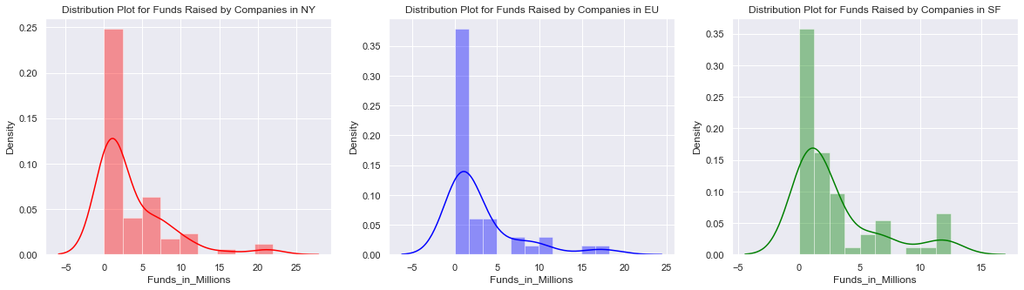

```python
fig2,ax2 = plt.subplots(1,3)
fig2.set_figheight(5)
fig2.set_figwidth(20)

sns.distplot(NY_e,ax=ax2[0],color='Red')

sns.distplot(EU_e,ax=ax2[1],color='Blue')
sns.distplot(SF_e,ax=ax2[2],color='Green')

ax2[0].set_title('Distribution Plot for Funds Raised by Companies in NY')
ax2[1].set_title('Distribution Plot for Funds Raised by Companies in EU')
ax2[2].set_title('Distribution Plot for Funds Raised by Companies in SF')


plt.show()
```

**From above graph we can see the three distribution are quite similar, we can conclude by performing the test**  
**There are many test like z-test,t-test etc but since this particular problem contain more than two parameter we can go with ANOVA test**

```python
from scipy.stats import f_oneway

a_stat,a_pvalue = f_oneway(NY_e,SF_e,EU_e)

if a_pvalue <= 0.05:     #In most cases we take significant level of 5%
    print(f'We reject the Null Hypothesis since p-value({round(a_pvalue,3)}) is < alpha(0.05) ' )
else:
    print(f'We fail to reject the Null Hypothesis since p-value({round(a_pvalue,3)}) is > alpha(0.05) ' )
```

```
We fail to reject the Null Hypothesis since p-value(0.628) is > alpha(0.05)
```

**I would suggest for improvement such as collecting data on Funds more accurately, adding more attribute like number of employees in the company could give us idea on how big the startup is or at what stage the company is in.**